# **Cyclistic BikeShare data reveal bussiness opportunities**

### 5.2.3 Filter out and/or replacing missing data

The data set contains multiple types of missing and inconsistent data that need to be processed before analyses. Process the varying terminology throughout the eyars into consistent formats.

```r
# as we could not determine what membership 'Dependent' refers to without
# consulting Cyclistic, those data will be excluded for this analysis.
ride_data <- filter(ride_data, membership != "Dependent")

# we can assume 'customer' is the same as 'casual' and 'Subscriber' equals
# 'member'.  we will replace the membership descriptions by 'Customer' and
# 'Subscriber'.
ride_data$membership <- as.character(ride_data$membership)
ride_data$membership[ride_data$membership == "casual"] <- "Customer"
ride_data$membership[ride_data$membership == "member"] <- "Subscriber"
```

Remove unsalvageable missing data, which lack station id. This section could arguable be included for comparing trip duration and ride distance, but we have more than adequate data and therefore can afford to remove these questionable entries.

```r
# remove rows without station ids as unreliable data.
ride_data <- ride_data[!is.na(ride_data$start_station_id) & !is.na(ride_data$end_station_id),
    ]
# remove rows without start and end datetime.
ride_data <- ride_data[!is.na(ride_data$start_datetime) & !is.na(ride_data$end_datetime),
    ]
```

Assuming the station ids have not been changed through out the years, we can use station ids to fill in missing geospatial coordinates before 2020.

```r
# create a dataframe for start stations and end stations.
start_station_info <- ride_data %>%
    select(start_station_id, start_station_name, start_station_lon, start_station_lat) %>%
    drop_na() %>%
    distinct(start_station_id, .keep_all = TRUE)

end_station_info <- ride_data %>%
    select(end_station_id, end_station_name, end_station_lon, end_station_lat) %>%
    drop_na() %>%
    distinct(end_station_id, .keep_all = TRUE)

# fill in longitude and latitude based on matching station ids.
ride_data <- inner_join(ride_data, start_station_info, by = c("start_station_id",
    "start_station_name"))
ride_data <- ride_data %>%
    select(-c(start_station_lon.x, start_station_lat.x)) %>%
    rename(start_station_lon = start_station_lon.y, start_station_lat = start_station_lat.y)

ride_data$start_year <- year(ride_data$start_datetime)
ride_data$start_month <- month(ride_data$start_datetime, label = TRUE, abbr = TRUE)
ride_data$start_ym <- as_factor(format(ride_data$start_datetime, "%Y-%m"))

ride_data <- inner_join(ride_data, end_station_info, by = c("end_station_id", "end_station_name"))
ride_data <- ride_data %>%
    select(-c("csv_names", "end_station_lon.x", "end_station_lat.x")) %>%
    rename(end_station_lon = end_station_lon.y, end_station_lat = end_station_lat.y)
```

## 5.3 Data exploration and analyses using R

### 5.3.1 Compute metrics for comparisons between subscribers and customers

Compute days of week, trip duration, and ride distance.

```r
# get day of week from datetime column.
ride_data$start_day <- wday(ride_data$start_datetime, label = TRUE, abbr = TRUE)
ride_data$end_day <- wday(ride_data$end_datetime, label = TRUE, abbr = TRUE)

# compute the trip duration some of the start time are later than the end time,
# which are likely input errors. We can take the absolute values of the
# difference between two dates to circumvent the potential erroneous inputs.
ride_data$trip_duration <- as_hms(abs(difftime(ride_data$end_datetime, ride_data$start_datetime)))

# compute the direct distance between start and end stations.
ride_data$rdistance <- distGeo(ride_data[, 9:10], ride_data[, 14:15])


# some users have trip duration of 0, which suggest they may be switching among
# bikes for functional or better fitting bikes.  we can filter out those rows
# as they don't necessary tell us the difference between subscribers and
# customers.
ride_data <- ride_data %>%
    filter(start_datetime != end_datetime)

invisible(gc())
```

## 5.4 Analyse the behavioural difference between subscribers and customers.

### 5.4.1 Number of ride as a primary metric

Looking at the number of rides from 2013 to 2023 as a whole.

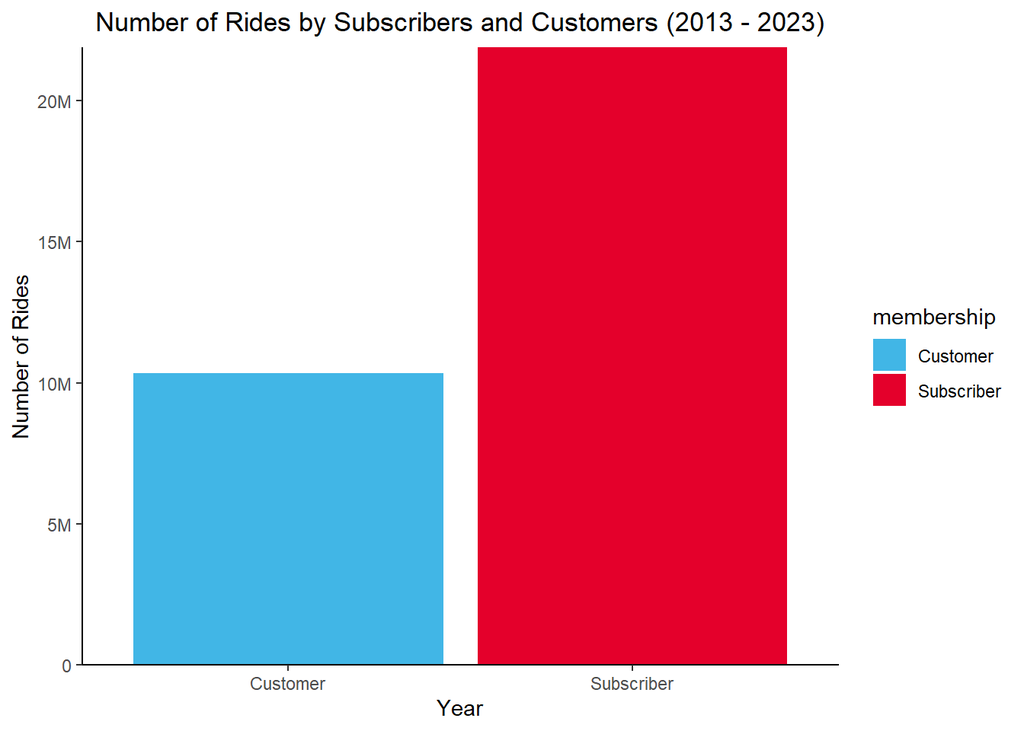

```r
# counting the number of rides using the entire data set.
num_ride_all <- data.frame(membership = c("Subscriber", "Customer"), number_of_rides = c(sum(ride_data$membership ==
    "Subscriber", na.rm = TRUE), sum(ride_data$membership == "Customer", na.rm = TRUE)))
kable(num_ride_all, style = "rmarkdown")

p_num_ride_all <- ggplot(num_ride_all, aes(x = membership, y = number_of_rides, fill = membership)) +
    geom_bar(position = "dodge", stat = "identity") + scale_y_continuous(labels = scales::label_number(scale_cut = cut_short_scale()),
    expand = c(0, 0), limits = c(0, NA)) + xlab("Year") + ylab("Number of Rides") +
    ggtitle("Number of Rides by Subscribers and Customers (2013 - 2023)") + scale_fill_manual(name = "membership",
    values = c("#41B6E6", "#E4002B")) + theme_classic() + theme(plot.title = element_text(hjust = 0.5))
p_num_ride_all
```

```r
invisible(gc())
```

| membership | number_of_rides |
| --- | --- |
| Subscriber | 21897708 |
| Customer | 10350876 |

Result of this section: (1) subscribers ride nearly twice as often as customers overall.

Comparing the number of rides from 2013 to 2023 annually.

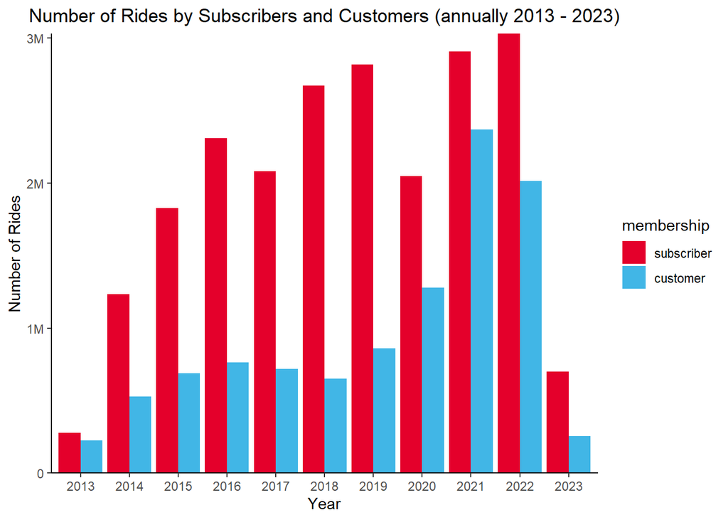

```r
# counting the number of rides annually.
num_ride_year <- data.frame(
  year = as.factor(c(2013, 2014, 2015, 2016, 2017, 2018, 2019, 2020, 2021, 2022, 2023)),
  subscriber = c(sum(ride_data$membership == "Subscriber" & ride_data$start_year == 2013, na.rm=TRUE),
                 sum(ride_data$membership == "Subscriber" & ride_data$start_year == 2014, na.rm=TRUE),
                 sum(ride_data$membership == "Subscriber" & ride_data$start_year == 2015, na.rm=TRUE),
                 sum(ride_data$membership == "Subscriber" & ride_data$start_year == 2016, na.rm=TRUE),
                 sum(ride_data$membership == "Subscriber" & ride_data$start_year == 2017, na.rm=TRUE),
                 sum(ride_data$membership == "Subscriber" & ride_data$start_year == 2018, na.rm=TRUE),
                 sum(ride_data$membership == "Subscriber" & ride_data$start_year == 2019, na.rm=TRUE),
                 sum(ride_data$membership == "Subscriber" & ride_data$start_year == 2020, na.rm=TRUE),
                 sum(ride_data$membership == "Subscriber" & ride_data$start_year == 2021, na.rm=TRUE),
                 sum(ride_data$membership == "Subscriber" & ride_data$start_year == 2022, na.rm=TRUE),
                 sum(ride_data$membership == "Subscriber" & ride_data$start_year == 2023, na.rm=TRUE)),

  customer = c(sum(ride_data$membership == "Customer" & ride_data$start_year == 2013, na.rm=TRUE),
               sum(ride_data$membership == "Customer" & ride_data$start_year == 2014, na.rm=TRUE),
               sum(ride_data$membership == "Customer" & ride_data$start_year == 2015, na.rm=TRUE),
               sum(ride_data$membership == "Customer" & ride_data$start_year == 2016, na.rm=TRUE),
               sum(ride_data$membership == "Customer" & ride_data$start_year == 2017, na.rm=TRUE),
               sum(ride_data$membership == "Customer" & ride_data$start_year == 2018, na.rm=TRUE),
               sum(ride_data$membership == "Customer" & ride_data$start_year == 2019, na.rm=TRUE),
               sum(ride_data$membership == "Customer" & ride_data$start_year == 2020, na.rm=TRUE),
               sum(ride_data$membership == "Customer" & ride_data$start_year == 2021, na.rm=TRUE),
               sum(ride_data$membership == "Customer" & ride_data$start_year == 2022, na.rm=TRUE),
               sum(ride_data$membership == "Customer" & ride_data$start_year == 2023, na.rm=TRUE))
)

num_ride_year <- melt(num_ride_year, id.vars = "year")
colnames(num_ride_year) <- c("year", "membership", "number_of_rides")
kable(num_ride_year, style = "rmarkdown")

p_num_ride_year <- ggplot(num_ride_year, aes(x = year, y = number_of_rides, fill = membership)) +
  geom_bar(position="dodge", stat="identity") +
  scale_y_continuous(labels = scales::label_number(scale_cut = cut_short_scale()),
                     expand = c(0, 0), limits = c(0, NA)) +
  xlab("Year") +
  ylab("Number of Rides") +
  ggtitle("Number of Rides by Subscribers and Customers (annually 2013 - 2023)") +
  scale_fill_manual(name = "membership", values = c("#E4002B", "#41B6E6")) +
  theme_classic() +
  theme(plot.title = element_text(hjust = 0.5))
p_num_ride_year
```

```r
invisible(gc())
```

| year | membership | number_of_rides |
| --- | --- | --- |
| 2013 | subscriber | 277757 |
| 2014 | subscriber | 1232551 |
| 2015 | subscriber | 1827470 |
| 2016 | subscriber | 2306753 |
| 2017 | subscriber | 2081928 |
| 2018 | subscriber | 2671428 |
| 2019 | subscriber | 2815915 |
| 2020 | subscriber | 2047181 |
| 2021 | subscriber | 2905910 |
| 2022 | subscriber | 3029613 |
| 2023 | subscriber | 701202 |
| 2013 | customer | 225376 |
| 2014 | customer | 528563 |
| 2015 | customer | 687468 |
| 2016 | customer | 764236 |
| 2017 | customer | 717651 |
| 2018 | customer | 649506 |
| 2019 | customer | 861881 |
| 2020 | customer | 1276657 |
| 2021 | customer | 2369388 |
| 2022 | customer | 2014675 |
| 2023 | customer | 255475 |

Result of this section: (1) more rides are taken by subscribers than customers since 2013. (2) number of rides by subscribers dropped in 2020 during the COVID-19 pandemic but has recovered and increased in 2021 and 2022. (3) data from 2023 is limited and does not represent a decrease in number of rides (4) more rides by subscribers take place on Monday to Friday, which suggests subscribers may have been using Cyclistic service commuting to and from work.

Comparing the number of rides by weekdays.

```r
num_ride_wday <- data.frame(
  weekday = as.factor(c(rep("Mon", 2), rep("Tue", 2), rep("Wed", 2), rep("Thu", 2), rep("Fri", 2), rep("Sat", 2), rep("Sun", 2))),
  membership = as.factor(c("Subscriber", "Customer")),
  year_2013 = c(sum(ride_data$start_day == "Mon" & ride_data$start_year == 2013 & ride_data$membership == "Subscriber", na.rm=TRUE),
                sum(ride_data$start_day == "Mon" & ride_data$start_year == 2013 & ride_data$membership == "Customer", na.rm=TRUE),
                sum(ride_data$start_day == "Tue" & ride_data$start_year == 2013 & ride_data$membership == "Subscriber", na.rm=TRUE),
                sum(ride_data$start_day == "Tue" & ride_data$start_year == 2013 & ride_data$membership == "Customer", na.rm=TRUE),
                sum(ride_data$start_day == "Wed" & ride_data$start_year == 2013 & ride_data$membership == "Subscriber", na.rm=TRUE),
                sum(ride_data$start_day == "Wed" & ride_data$start_year == 2013 & ride_data$membership == "Customer", na.rm=TRUE),
                sum(ride_data$start_day == "Thu" & ride_data$start_year == 2013 & ride_data$membership == "Subscriber", na.rm=TRUE),
                sum(ride_data$start_day == "Thu" & ride_data$start_year == 2013 & ride_data$membership == "Customer", na.rm=TRUE),
                sum(ride_data$start_day == "Fri" & ride_data$start_year == 2013 & ride_data$membership == "Subscriber", na.rm=TRUE),
                sum(ride_data$start_day == "Fri" & ride_data$start_year == 2013 & ride_data$membership == "Customer", na.rm=TRUE),
                sum(ride_data$start_day == "Sat" & ride_data$start_year == 2013 & ride_data$membership == "Subscriber", na.rm=TRUE),
                sum(ride_data$start_day == "Sat" & ride_data$start_year == 2013 & ride_data$membership == "Customer", na.rm=TRUE),
                sum(ride_data$start_day == "Sun" & ride_data$start_year == 2013 & ride_data$membership == "Subscriber", na.rm=TRUE),
                sum(ride_data$start_day == "Sun" & ride_data$start_year == 2013 & ride_data$membership == "Customer", na.rm=TRUE)),

  year_2014 = c(sum(ride_data$start_day == "Mon" & ride_data$start_year == 2014 & ride_data$membership == "Subscriber", na.rm=TRUE),
                sum(ride_data$start_day == "Mon" & ride_data$start_year == 2014 & ride_data$membership == "Customer", na.rm=TRUE),
                sum(ride_data$start_day == "Tue" & ride_data$start_year == 2014 & ride_data$membership == "Subscriber", na.rm=TRUE),
                sum(ride_data$start_day == "Tue" & ride_data$start_year == 2014 & ride_data$membership == "Customer", na.rm=TRUE),
                sum(ride_data$start_day == "Wed" & ride_data$start_year == 2014 & ride_data$membership == "Subscriber", na.rm=TRUE),
                sum(ride_data$start_day == "Wed" & ride_data$start_year == 2014 & ride_data$membership == "Customer", na.rm=TRUE),
                sum(ride_data$start_day == "Thu" & ride_data$start_year == 2014 & ride_data$membership == "Subscriber", na.rm=TRUE),
                sum(ride_data$start_day == "Thu" & ride_data$start_year == 2014 & ride_data$membership == "Customer", na.rm=TRUE),
                sum(ride_data$start_day == "Fri" & ride_data$start_year == 2014 & ride_data$membership == "Subscriber", na.rm=TRUE),
                sum(ride_data$start_day == "Fri" & ride_data$start_year == 2014 & ride_data$membership == "Customer", na.rm=TRUE),
                sum(ride_data$start_day == "Sat" & ride_data$start_year == 2014 & ride_data$membership == "Subscriber", na.rm=TRUE),
                sum(ride_data$start_day == "Sat" & ride_data$start_year == 2014 & ride_data$membership == "Customer", na.rm=TRUE),
                sum(ride_data$start_day == "Sun" & ride_data$start_year == 2014 & ride_data$membership == "Subscriber", na.rm=TRUE),
                sum(ride_data$start_day == "Sun" & ride_data$start_year == 2014 & ride_data$membership == "Customer", na.rm=TRUE)),

  year_2015 = c(sum(ride_data$start_day == "Mon" & ride_data$start_year == 2015 & ride_data$membership == "Subscriber", na.rm=TRUE),
                sum(ride_data$start_day == "Mon" & ride_data$start_year == 2015 & ride_data$membership == "Customer", na.rm=TRUE),
                sum(ride_data$start_day == "Tue" & ride_data$start_year == 2015 & ride_data$membership == "Subscriber", na.rm=TRUE),
                sum(ride_data$start_day == "Tue" & ride_data$start_year == 2015 & ride_data$membership == "Customer", na.rm=TRUE),
                sum(ride_data$start_day == "Wed" & ride_data$start_year == 2015 & ride_data$membership == "Subscriber", na.rm=TRUE),
                sum(ride_data$start_day == "Wed" & ride_data$start_year == 2015 & ride_data$membership == "Customer", na.rm=TRUE),
                sum(ride_data$start_day == "Thu" & ride_data$start_year == 2015 & ride_data$membership == "Subscriber", na.rm=TRUE),
                sum(ride_data$start_day == "Thu" & ride_data$start_year == 2015 & ride_data$membership == "Customer", na.rm=TRUE),
                sum(ride_data$start_day == "Fri" & ride_data$start_year == 2015 & ride_data$membership == "Subscriber", na.rm=TRUE),
                sum(ride_data$start_day == "Fri" & ride_data$start_year == 2015 & ride_data$membership == "Customer", na.rm=TRUE),
                sum(ride_data$start_day == "Sat" & ride_data$start_year == 2015 & ride_data$membership == "Subscriber", na.rm=TRUE),
                sum(ride_data$start_day == "Sat" & ride_data$start_year == 2015 & ride_data$membership == "Customer", na.rm=TRUE),
                sum(ride_data$start_day == "Sun" & ride_data$start_year == 2015 & ride_data$membership == "Subscriber", na.rm=TRUE),
                sum(ride_data$start_day == "Sun" & ride_data$start_year == 2015 & ride_data$membership == "Customer", na.rm=TRUE)),

  year_2016 = c(sum(ride_data$start_day == "Mon" & ride_data$start_year == 2016 & ride_data$membership == "Subscriber", na.rm=TRUE),
                sum(ride_data$start_day == "Mon" & ride_data$start_year == 2016 & ride_data$membership == "Customer", na.rm=TRUE),
                sum(ride_data$start_day == "Tue" & ride_data$start_year == 2016 & ride_data$membership == "Subscriber", na.rm=TRUE),
                sum(ride_data$start_day == "Tue" & ride_data$start_year == 2016 & ride_data$membership == "Customer", na.rm=TRUE),
                sum(ride_data$start_day == "Wed" & ride_data$start_year == 2016 & ride_data$membership == "Subscriber", na.rm=TRUE),
                sum(ride_data$start_day == "Wed" & ride_data$start_year == 2016 & ride_data$membership == "Customer", na.rm=TRUE),
                sum(ride_data$start_day == "Thu" & ride_data$start_year == 2016 & ride_data$membership == "Subscriber", na.rm=TRUE),
                sum(ride_data$start_day == "Thu" & ride_data$start_year == 2016 & ride_data$membership == "Customer", na.rm=TRUE),
                sum(ride_data$start_day == "Fri" & ride_data$start_year == 2016 & ride_data$membership == "Subscriber", na.rm=TRUE),
                sum(ride_data$start_day == "Fri" & ride_data$start_year == 2016 & ride_data$membership == "Customer", na.rm=TRUE),
                sum(ride_data$start_day == "Sat" & ride_data$start_year == 2016 & ride_data$membership == "Subscriber", na.rm=TRUE),
                sum(ride_data$start_day == "Sat" & ride_data$start_year == 2016 & ride_data$membership == "Customer", na.rm=TRUE),
                sum(ride_data$start_day == "Sun" & ride_data$start_year == 2016 & ride_data$membership == "Subscriber", na.rm=TRUE),
                sum(ride_data$start_day == "Sun" & ride_data$start_year == 2016 & ride_data$membership == "Customer", na.rm=TRUE)),
```

```r
  year_2017 = c(sum(ride_data$start_day == "Mon" & ride_data$start_year == 2017 & ride_data$membership == "Subscriber", na.rm=TRUE),
                sum(ride_data$start_day == "Mon" & ride_data$start_year == 2017 & ride_data$membership == "Customer", na.rm=TRUE),
                sum(ride_data$start_day == "Tue" & ride_data$start_year == 2017 & ride_data$membership == "Subscriber", na.rm=TRUE),
                sum(ride_data$start_day == "Tue" & ride_data$start_year == 2017 & ride_data$membership == "Customer", na.rm=TRUE),
                sum(ride_data$start_day == "Wed" & ride_data$start_year == 2017 & ride_data$membership == "Subscriber", na.rm=TRUE),
                sum(ride_data$start_day == "Wed" & ride_data$start_year == 2017 & ride_data$membership == "Customer", na.rm=TRUE),
                sum(ride_data$start_day == "Thu" & ride_data$start_year == 2017 & ride_data$membership == "Subscriber", na.rm=TRUE),
                sum(ride_data$start_day == "Thu" & ride_data$start_year == 2017 & ride_data$membership == "Customer", na.rm=TRUE),
                sum(ride_data$start_day == "Fri" & ride_data$start_year == 2017 & ride_data$membership == "Subscriber", na.rm=TRUE),
                sum(ride_data$start_day == "Fri" & ride_data$start_year == 2017 & ride_data$membership == "Customer", na.rm=TRUE),
                sum(ride_data$start_day == "Sat" & ride_data$start_year == 2017 & ride_data$membership == "Subscriber", na.rm=TRUE),
                sum(ride_data$start_day == "Sat" & ride_data$start_year == 2017 & ride_data$membership == "Customer", na.rm=TRUE),
                sum(ride_data$start_day == "Sun" & ride_data$start_year == 2017 & ride_data$membership == "Subscriber", na.rm=TRUE),
                sum(ride_data$start_day == "Sun" & ride_data$start_year == 2017 & ride_data$membership == "Customer", na.rm=TRUE)),

  year_2018 = c(sum(ride_data$start_day == "Mon" & ride_data$start_year == 2018 & ride_data$membership == "Subscriber", na.rm=TRUE),
                sum(ride_data$start_day == "Mon" & ride_data$start_year == 2018 & ride_data$membership == "Customer", na.rm=TRUE),
                sum(ride_data$start_day == "Tue" & ride_data$start_year == 2018 & ride_data$membership == "Subscriber", na.rm=TRUE),
                sum(ride_data$start_day == "Tue" & ride_data$start_year == 2018 & ride_data$membership == "Customer", na.rm=TRUE),
                sum(ride_data$start_day == "Wed" & ride_data$start_year == 2018 & ride_data$membership == "Subscriber", na.rm=TRUE),
                sum(ride_data$start_day == "Wed" & ride_data$start_year == 2018 & ride_data$membership == "Customer", na.rm=TRUE),
                sum(ride_data$start_day == "Thu" & ride_data$start_year == 2018 & ride_data$membership == "Subscriber", na.rm=TRUE),
                sum(ride_data$start_day == "Thu" & ride_data$start_year == 2018 & ride_data$membership == "Customer", na.rm=TRUE),
                sum(ride_data$start_day == "Fri" & ride_data$start_year == 2018 & ride_data$membership == "Subscriber", na.rm=TRUE),
                sum(ride_data$start_day == "Fri" & ride_data$start_year == 2018 & ride_data$membership == "Customer", na.rm=TRUE),
                sum(ride_data$start_day == "Sat" & ride_data$start_year == 2018 & ride_data$membership == "Subscriber", na.rm=TRUE),
                sum(ride_data$start_day == "Sat" & ride_data$start_year == 2018 & ride_data$membership == "Customer", na.rm=TRUE),
                sum(ride_data$start_day == "Sun" & ride_data$start_year == 2018 & ride_data$membership == "Subscriber", na.rm=TRUE),
                sum(ride_data$start_day == "Sun" & ride_data$start_year == 2018 & ride_data$membership == "Customer", na.rm=TRUE)),

  year_2019 = c(sum(ride_data$start_day == "Mon" & ride_data$start_year == 2019 & ride_data$membership == "Subscriber", na.rm=TRUE),
                sum(ride_data$start_day == "Mon" & ride_data$start_year == 2019 & ride_data$membership == "Customer", na.rm=TRUE),
                sum(ride_data$start_day == "Tue" & ride_data$start_year == 2019 & ride_data$membership == "Subscriber", na.rm=TRUE),
                sum(ride_data$start_day == "Tue" & ride_data$start_year == 2019 & ride_data$membership == "Customer", na.rm=TRUE),
                sum(ride_data$start_day == "Wed" & ride_data$start_year == 2019 & ride_data$membership == "Subscriber", na.rm=TRUE),
                sum(ride_data$start_day == "Wed" & ride_data$start_year == 2019 & ride_data$membership == "Customer", na.rm=TRUE),
                sum(ride_data$start_day == "Thu" & ride_data$start_year == 2019 & ride_data$membership == "Subscriber", na.rm=TRUE),
                sum(ride_data$start_day == "Thu" & ride_data$start_year == 2019 & ride_data$membership == "Customer", na.rm=TRUE),
                sum(ride_data$start_day == "Fri" & ride_data$start_year == 2019 & ride_data$membership == "Subscriber", na.rm=TRUE),
                sum(ride_data$start_day == "Fri" & ride_data$start_year == 2019 & ride_data$membership == "Customer", na.rm=TRUE),
                sum(ride_data$start_day == "Sat" & ride_data$start_year == 2019 & ride_data$membership == "Subscriber", na.rm=TRUE),
                sum(ride_data$start_day == "Sat" & ride_data$start_year == 2019 & ride_data$membership == "Customer", na.rm=TRUE),
                sum(ride_data$start_day == "Sun" & ride_data$start_year == 2019 & ride_data$membership == "Subscriber", na.rm=TRUE),
                sum(ride_data$start_day == "Sun" & ride_data$start_year == 2019 & ride_data$membership == "Customer", na.rm=TRUE)),

  year_2020 = c(sum(ride_data$start_day == "Mon" & ride_data$start_year == 2020 & ride_data$membership == "Subscriber", na.rm=TRUE),
                sum(ride_data$start_day == "Mon" & ride_data$start_year == 2020 & ride_data$membership == "Customer", na.rm=TRUE),
                sum(ride_data$start_day == "Tue" & ride_data$start_year == 2020 & ride_data$membership == "Subscriber", na.rm=TRUE),
                sum(ride_data$start_day == "Tue" & ride_data$start_year == 2020 & ride_data$membership == "Customer", na.rm=TRUE),
                sum(ride_data$start_day == "Wed" & ride_data$start_year == 2020 & ride_data$membership == "Subscriber", na.rm=TRUE),
                sum(ride_data$start_day == "Wed" & ride_data$start_year == 2020 & ride_data$membership == "Customer", na.rm=TRUE),
                sum(ride_data$start_day == "Thu" & ride_data$start_year == 2020 & ride_data$membership == "Subscriber", na.rm=TRUE),
                sum(ride_data$start_day == "Thu" & ride_data$start_year == 2020 & ride_data$membership == "Customer", na.rm=TRUE),
                sum(ride_data$start_day == "Fri" & ride_data$start_year == 2020 & ride_data$membership == "Subscriber", na.rm=TRUE),
                sum(ride_data$start_day == "Fri" & ride_data$start_year == 2020 & ride_data$membership == "Customer", na.rm=TRUE),
                sum(ride_data$start_day == "Sat" & ride_data$start_year == 2020 & ride_data$membership == "Subscriber", na.rm=TRUE),
                sum(ride_data$start_day == "Sat" & ride_data$start_year == 2020 & ride_data$membership == "Customer", na.rm=TRUE),
                sum(ride_data$start_day == "Sun" & ride_data$start_year == 2020 & ride_data$membership == "Subscriber", na.rm=TRUE),
                sum(ride_data$start_day == "Sun" & ride_data$start_year == 2020 & ride_data$membership == "Customer", na.rm=TRUE)),
```

[figure not shown]

```r
  year_2021 = c(sum(ride_data$start_day == "Mon" & ride_data$start_year == 2021 & ride_data$membership == "Subscriber", na.rm=TRUE),
                sum(ride_data$start_day == "Mon" & ride_data$start_year == 2021 & ride_data$membership == "Customer", na.rm=TRUE),
                sum(ride_data$start_day == "Tue" & ride_data$start_year == 2021 & ride_data$membership == "Subscriber", na.rm=TRUE),
                sum(ride_data$start_day == "Tue" & ride_data$start_year == 2021 & ride_data$membership == "Customer", na.rm=TRUE),
                sum(ride_data$start_day == "Wed" & ride_data$start_year == 2021 & ride_data$membership == "Subscriber", na.rm=TRUE),
                sum(ride_data$start_day == "Wed" & ride_data$start_year == 2021 & ride_data$membership == "Customer", na.rm=TRUE),
                sum(ride_data$start_day == "Thu" & ride_data$start_year == 2021 & ride_data$membership == "Subscriber", na.rm=TRUE),
                sum(ride_data$start_day == "Thu" & ride_data$start_year == 2021 & ride_data$membership == "Customer", na.rm=TRUE),
                sum(ride_data$start_day == "Fri" & ride_data$start_year == 2021 & ride_data$membership == "Subscriber", na.rm=TRUE),
                sum(ride_data$start_day == "Fri" & ride_data$start_year == 2021 & ride_data$membership == "Customer", na.rm=TRUE),
                sum(ride_data$start_day == "Sat" & ride_data$start_year == 2021 & ride_data$membership == "Subscriber", na.rm=TRUE),
                sum(ride_data$start_day == "Sat" & ride_data$start_year == 2021 & ride_data$membership == "Customer", na.rm=TRUE),
                sum(ride_data$start_day == "Sun" & ride_data$start_year == 2021 & ride_data$membership == "Subscriber", na.rm=TRUE),
                sum(ride_data$start_day == "Sun" & ride_data$start_year == 2021 & ride_data$membership == "Customer", na.rm=TRUE)),

  year_2022 = c(sum(ride_data$start_day == "Mon" & ride_data$start_year == 2022 & ride_data$membership == "Subscriber", na.rm=TRUE),
                sum(ride_data$start_day == "Mon" & ride_data$start_year == 2022 & ride_data$membership == "Customer", na.rm=TRUE),
                sum(ride_data$start_day == "Tue" & ride_data$start_year == 2022 & ride_data$membership == "Subscriber", na.rm=TRUE),
                sum(ride_data$start_day == "Tue" & ride_data$start_year == 2022 & ride_data$membership == "Customer", na.rm=TRUE),
                sum(ride_data$start_day == "Wed" & ride_data$start_year == 2022 & ride_data$membership == "Subscriber", na.rm=TRUE),
                sum(ride_data$start_day == "Wed" & ride_data$start_year == 2022 & ride_data$membership == "Customer", na.rm=TRUE),
                sum(ride_data$start_day == "Thu" & ride_data$start_year == 2022 & ride_data$membership == "Subscriber", na.rm=TRUE),
                sum(ride_data$start_day == "Thu" & ride_data$start_year == 2022 & ride_data$membership == "Customer", na.rm=TRUE),
                sum(ride_data$start_day == "Fri" & ride_data$start_year == 2022 & ride_data$membership == "Subscriber", na.rm=TRUE),
                sum(ride_data$start_day == "Fri" & ride_data$start_year == 2022 & ride_data$membership == "Customer", na.rm=TRUE),
                sum(ride_data$start_day == "Sat" & ride_data$start_year == 2022 & ride_data$membership == "Subscriber", na.rm=TRUE),
                sum(ride_data$start_day == "Sat" & ride_data$start_year == 2022 & ride_data$membership == "Customer", na.rm=TRUE),
                sum(ride_data$start_day == "Sun" & ride_data$start_year == 2022 & ride_data$membership == "Subscriber", na.rm=TRUE),
                sum(ride_data$start_day == "Sun" & ride_data$start_year == 2022 & ride_data$membership == "Customer", na.rm=TRUE)),

  year_2023 = c(sum(ride_data$start_day == "Mon" & ride_data$start_year == 2023 & ride_data$membership == "Subscriber", na.rm=TRUE),
                sum(ride_data$start_day == "Mon" & ride_data$start_year == 2023 & ride_data$membership == "Customer", na.rm=TRUE),
                sum(ride_data$start_day == "Tue" & ride_data$start_year == 2023 & ride_data$membership == "Subscriber", na.rm=TRUE),
                sum(ride_data$start_day == "Tue" & ride_data$start_year == 2023 & ride_data$membership == "Customer", na.rm=TRUE),
                sum(ride_data$start_day == "Wed" & ride_data$start_year == 2023 & ride_data$membership == "Subscriber", na.rm=TRUE),
                sum(ride_data$start_day == "Wed" & ride_data$start_year == 2023 & ride_data$membership == "Customer", na.rm=TRUE),
                sum(ride_data$start_day == "Thu" & ride_data$start_year == 2023 & ride_data$membership == "Subscriber", na.rm=TRUE),
                sum(ride_data$start_day == "Thu" & ride_data$start_year == 2023 & ride_data$membership == "Customer", na.rm=TRUE),
                sum(ride_data$start_day == "Fri" & ride_data$start_year == 2023 & ride_data$membership == "Subscriber", na.rm=TRUE),
                sum(ride_data$start_day == "Fri" & ride_data$start_year == 2023 & ride_data$membership == "Customer", na.rm=TRUE),
                sum(ride_data$start_day == "Sat" & ride_data$start_year == 2023 & ride_data$membership == "Subscriber", na.rm=TRUE),
                sum(ride_data$start_day == "Sat" & ride_data$start_year == 2023 & ride_data$membership == "Customer", na.rm=TRUE),
                sum(ride_data$start_day == "Sun" & ride_data$start_year == 2023 & ride_data$membership == "Subscriber", na.rm=TRUE),
                sum(ride_data$start_day == "Sun" & ride_data$start_year == 2023 & ride_data$membership == "Customer", na.rm=TRUE))
)
kable(num_ride_wday, style = "rmarkdown")

num_ride_wday <- melt(num_ride_wday, id.vars = c("weekday", "membership"))
p_num_ride_wday <- ggplot(num_ride_wday, aes(x = factor(weekday, level = c("Mon", "Tue", "Wed", "Thu", "Fri", "Sat", "Sun")), y = value, fill = membership)) +
  geom_bar(position="dodge", stat="identity") +
  scale_y_continuous(labels = scales::label_number(scale_cut = cut_short_scale()), expand = c(0, 0), limits = c(0, NA)) +
  xlab("Weekdays") +
  ylab("Number of Rides") +
  ggtitle("Number of Rides by Subscribers and Customers (daily Monday - Sunday)") +
  scale_fill_manual(name = "membership", values = c("#41B6E6", "#E4002B")) +
  theme_classic() +
  theme(plot.title = element_text(hjust = 0.5))
p_num_ride_wday
```

```r
invisible(gc())
```

| weekday | membership | year_2013 | year_2014 | year_2015 | year_2016 | year_2017 | year_2018 | year_2019 | year_2020 | year_2021 | year_2022 | year_2023 |
| --- | --- | --- | --- | --- | --- | --- | --- | --- | --- | --- | --- | --- |
| Mon | Subscriber | 44417 | 187179 | 275431 | 363441 | 312865 | 406910 | 439513 | 275509 | 395573 | 430122 | 96802 |
| Mon | Customer | 26482 | 58235 | 77988 | 105825 | 90058 | 76986 | 99333 | 131064 | 269451 | 240692 | 27715 |
| Tue | Subscriber | 48570 | 200365 | 305882 | 388023 | 344790 | 448051 | 475494 | 298423 | 443467 | 473251 | 119011 |
| Tue | Customer | 20681 | 42728 | 62601 | 69330 | 68090 | 61642 | 86632 | 127600 | 258908 | 230844 | 34085 |
| Wed | Subscriber | 46085 | 202464 | 313480 | 351768 | 330761 | 457814 | 472225 | 311088 | 453083 | 476585 | 117253 |
| Wed | Customer | 19143 | 41653 | 63137 | 52198 | 53418 | 68473 | 87897 | 141436 | 261423 | 240054 | 35479 |
| Thu | Subscriber | 43698 | 199232 | 297409 | 364174 | 327316 | 446042 | 464602 | 309778 | 429129 | 484463 | 113188 |
| Thu | Customer | 21446 | 48740 | 67209 | 59571 | 56516 | 68083 | 99326 | 150671 | 268272 | 270152 | 37163 |
| Fri | Subscriber | 46804 | 191884 | 273264 | 358593 | 318077 | 402409 | 436501 | 306225 | 423986 | 424144 | 99833 |
| Fri | Customer | 29858 | 71094 | 85513 | 90516 | 79437 | 79238 | 118422 | 187868 | 342565 | 291705 | 38777 |
| Sat | Subscriber | 26330 | 131227 | 186330 | 247662 | 235915 | 265885 | 278532 | 291872 | 407217 | 394833 | 80394 |
| Sat | Customer | 56415 | 137543 | 176442 | 191756 | 199415 | 155347 | 203678 | 295720 | 519478 | 405868 | 45409 |
| Sun | Subscriber | 21853 | 120200 | 175674 | 233092 | 212204 | 244317 | 249048 | 254286 | 353455 | 346215 | 74721 |
| Sun | Customer | 51351 | 128570 | 154578 | 195040 | 170717 | 139737 | 166593 | 242298 | 449291 | 335360 | 36847 |

### 5.4.2 Bike type as a primary metric

Comparing the number of rides by bike type.

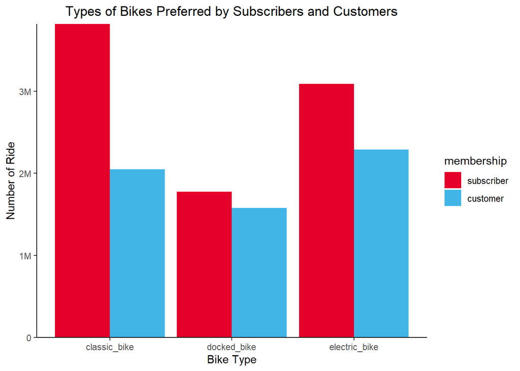

```r
# counting the number of rides based on bike type, which is only available from 2020 to 2023.
num_ride_bike_type <- data.frame(
  bike_type = as.factor(c("docked_bike", "electric_bike", "classic_bike")),
  subscriber = c(sum(ride_data$membership == "Subscriber" & ride_data$bike_type == "docked_bike", na.rm=TRUE),
                 sum(ride_data$membership == "Subscriber" & ride_data$bike_type == "electric_bike", na.rm=TRUE),
                 sum(ride_data$membership == "Subscriber" & ride_data$bike_type == "classic_bike", na.rm=TRUE)),

  customer = c(sum(ride_data$membership == "Customer" & ride_data$bike_type == "docked_bike", na.rm=TRUE),
               sum(ride_data$membership == "Customer" & ride_data$bike_type == "electric_bike", na.rm=TRUE),
               sum(ride_data$membership == "Customer" & ride_data$bike_type == "classic_bike", na.rm=TRUE))
)
num_ride_bike_type <- melt(num_ride_bike_type, id.vars = "bike_type")
colnames(num_ride_bike_type) <- c("bike_type", "membership", "number_of_rides")
kable(num_ride_bike_type, style = "rmarkdown")

p_num_ride_bike_type <- ggplot(num_ride_bike_type, aes(x = bike_type, y = number_of_rides, fill = membership)) +
  geom_bar(position="dodge", stat="identity") +
  xlab("Bike Type") +
  ylab("Number of Ride") +
  ggtitle("Types of Bikes Preferred by Subscribers and Customers") +
  scale_y_continuous(labels = scales::label_number(scale_cut = cut_short_scale()), expand = c(0, 0), limits = c(0, NA)) +
  scale_fill_manual(name = "membership", values = c("#E4002B", "#41B6E6")) +
  theme_classic() +
  theme(plot.title = element_text(hjust = 0.5))
p_num_ride_bike_type
```

```r
invisible(gc())
```

| bike_type | membership | number_of_rides |
| --- | --- | --- |
| docked_bike | subscriber | 1773876 |
| electric_bike | subscriber | 3090680 |
| classic_bike | subscriber | 3819350 |
| docked_bike | customer | 1577045 |
| electric_bike | customer | 2290301 |
| classic_bike | customer | 2048849 |

Result of this section: (1) customers use electric bikes most often but the difference is not substantial. (2) subscribers prefer classic bike over electric bike. (3) the low number of documented docked bike may be biased as they are documented only between January to July 2020.

### 5.4.3 Trip duration as a primary metric

Compute the descriptive statistics using the data from 2013 to 2023 as a whole.

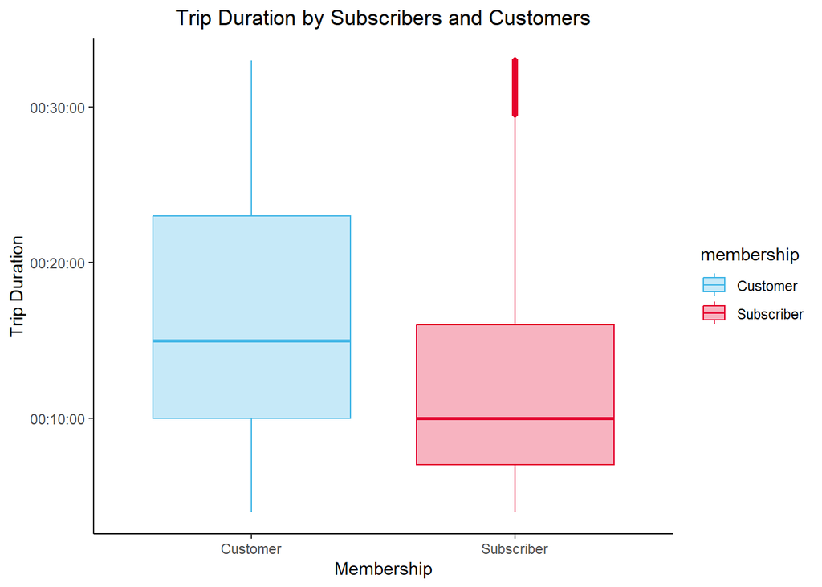

```r
# compute the max, min, mean, median, and mode of trip duration for subscribers and customers
tri_du_all <- data.frame(
  membership = c("Subscriber", "Customer"),
  max_duration = c(seconds_to_period(max(ride_data$trip_duration[ride_data$membership == "Subscriber"])),
                   seconds_to_period(max(ride_data$trip_duration[ride_data$membership == "Customer"]))),

  min_duration = c(seconds_to_period(min(ride_data$trip_duration[ride_data$membership == "Subscriber"])),
                   seconds_to_period(min(ride_data$trip_duration[ride_data$membership == "Customer"]))),

  mean_duration = c(round(seconds_to_period(mean(ride_data$trip_duration[ride_data$membership == "Subscriber"])), digits = 2),
                    round(seconds_to_period(mean(ride_data$trip_duration[ride_data$membership == "Customer"])), digits = 2)),

  median_duration = c(seconds_to_period(median(ride_data$trip_duration[ride_data$membership == "Subscriber"])),
                      seconds_to_period(median(ride_data$trip_duration[ride_data$membership == "Customer"]))),

  standard_deviantion = c(sd(ride_data$trip_duration[ride_data$membership == "Subscriber"]),
                          sd(ride_data$trip_duration[ride_data$membership == "Customer"]))
)
kable(tri_du_all, style = "rmarkdown")
# from the table, subscribers and customers have decent contrasts for means, median, and sd.

# create boxplot to visualise the descriptive statistics
p_tri_du_all_box <- ggplot(ride_data, aes(x =  membership, y = trip_duration, colour = membership, fill = membership)) +
  geom_boxplot(stat = "boxplot", alpha = 0.3) +
  scale_y_time(limits = quantile(ride_data$trip_duration, c(0.1, 0.9))) +
  xlab("Membership") +
  ylab("Trip Duration") +
  ggtitle("Trip Duration by Subscribers and Customers") +
  scale_colour_manual(name = "membership", values = c("#41B6E6", "#E4002B")) +
  scale_fill_manual(name = "membership", values = c("#41B6E6", "#E4002B")) +
  theme_classic() +
  theme(plot.title = element_text(hjust = 0.5))
p_tri_du_all_box
```

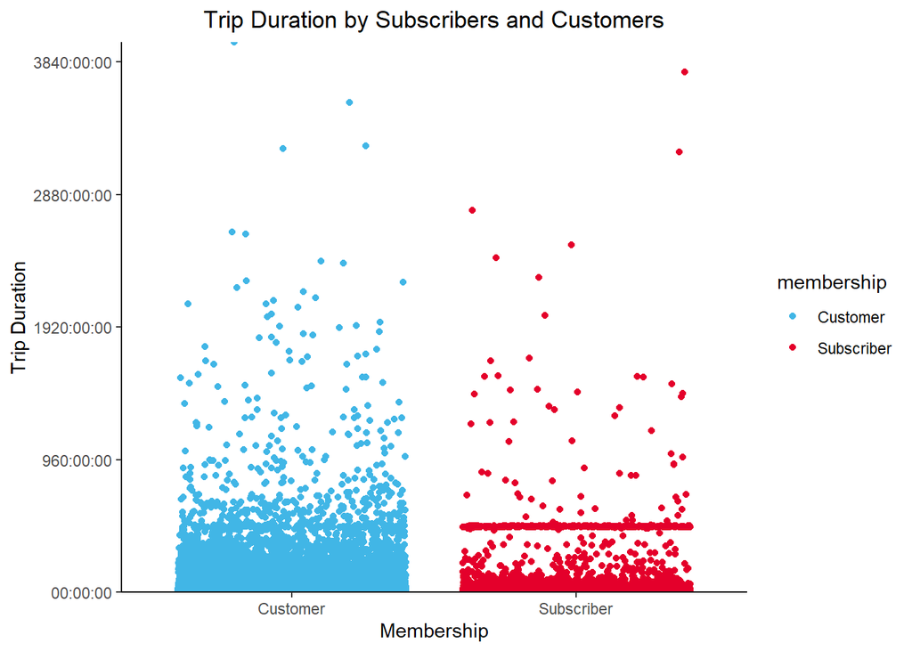

```r
# as the values beyond quantiles are cut off for better visuals on the boxplot, a scatter plot is created as a supplement.
p_tri_du_all_point <- ggplot(ride_data, aes(x =  membership, y = trip_duration, colour = membership)) +
  geom_jitter() +
  scale_y_time(expand = c(0, 0), limits = c(0, NA)) +
  xlab("Membership") +
  ylab("Trip Duration") +
  ggtitle("Trip Duration by Subscribers and Customers") +
  scale_colour_manual(name = "membership", values = c("#41B6E6", "#E4002B")) +
  theme_classic() +
  theme(plot.title = element_text(hjust = 0.5))
p_tri_du_all_point
```

```r
invisible(gc())
```

| membership | max_duration | min_duration | mean_duration | median_duration | standard_deviantion |
| --- | --- | --- | --- | --- | --- |
| Subscriber | 156d 23H 0M 0S | 59S | 13M 36.97S | 9M 59S | 10856.34 |
| Customer | 165d 23H 21M 0S | 59S | 36M 46.45S | 19M 0S | 26738.27 |

Result of this section: (1) mean and median of trip duration are both lower for subscribers than customers.

Using statistic tests to examine whether the observed difference between subscribers and customers is significant. A t-test is not performed because data is non-normally distributed. As an alternative, we will perform a non-parametric U-test that does not rely on sample normality.

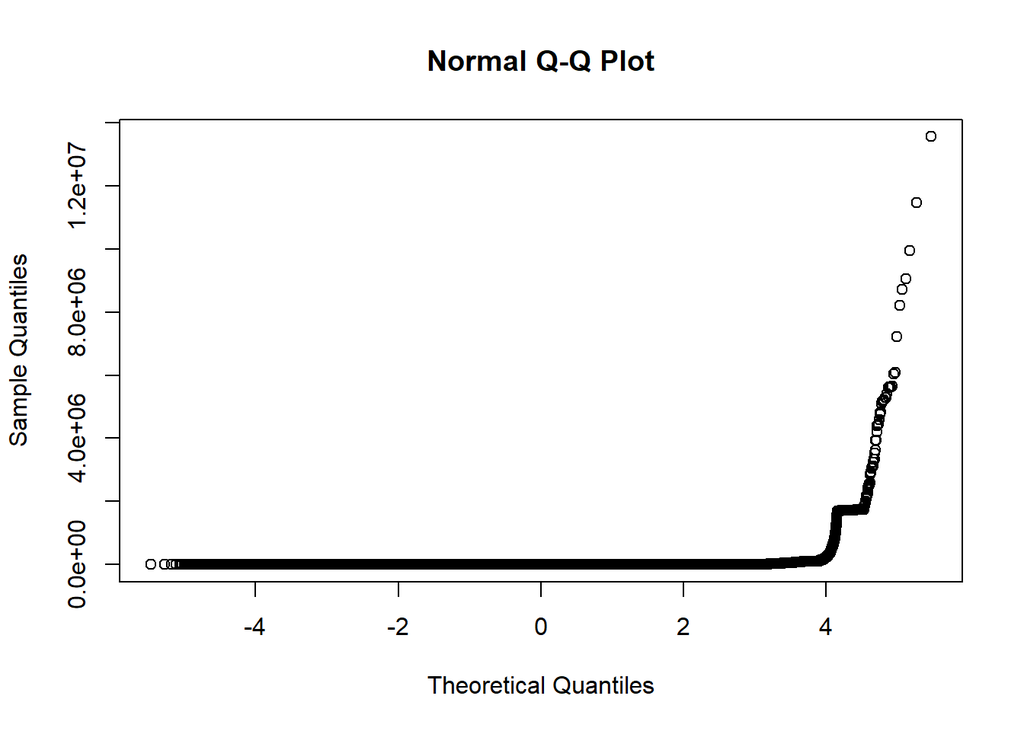

```r
# examine whether the entire data set is normally distributed.
qqnorm(ride_data$trip_duration[ride_data$membership == "Subscriber"])
```

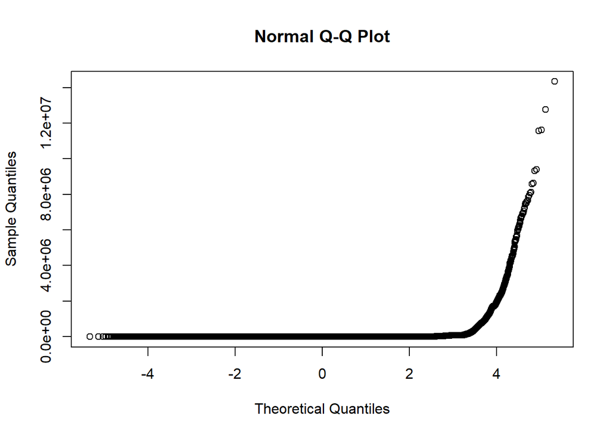

```r
qqnorm(ride_data$trip_duration[ride_data$membership == "Customer"])
```

```r
# as the data is non-normally distributed, we use a Two-sample Mann–Whitney U
# test from the coin package.  normality may not be necessary as real-world
# data tends to be non-normal as the sample size becomes huge.  convert the
# datetime format to dbl.
u_test_tri_du_all <- ride_data[, c(8, 18)]
u_test_tri_du_all$membership <- as.factor(u_test_tri_du_all$membership)
u_test_tri_du_all$trip_duration <- as.numeric(u_test_tri_du_all$trip_duration)
u_test_tri_du_all_result <- coin::wilcox_test(trip_duration ~ membership, data = u_test_tri_du_all,
    distribution = "approximate")
u_test_tri_du_all_result
invisible(gc())
```

```
##
##  Approximative Wilcoxon-Mann-Whitney Test
##
## data:  trip_duration by membership (Customer, Subscriber)
## Z = 2091.7, p-value < 1e-04
## alternative hypothesis: true mu is not equal to 0
```

Compute the descriptive statistics from 2013 to 2023 annually.

```r
tri_du_year <- data.frame(
  year = c(rep(2013, 2), rep(2014, 2), rep(2015, 2), rep(2016, 2), rep(2017, 2), rep(2018, 2),
           rep(2019, 2), rep(2020, 2), rep(2021, 2), rep(2022, 2), rep(2023, 2)),
  membership = c("Subscriber", "Customer"),
  max_duration = c(seconds_to_period(max(ride_data$trip_duration[ride_data$membership == "Subscriber" & ride_data$start_year == 2013])),
                   seconds_to_period(max(ride_data$trip_duration[ride_data$membership == "Customer" & ride_data$start_year == 2013])),
                   seconds_to_period(max(ride_data$trip_duration[ride_data$membership == "Subscriber" & ride_data$start_year == 2014])),
                   seconds_to_period(max(ride_data$trip_duration[ride_data$membership == "Customer" & ride_data$start_year == 2014])),
                   seconds_to_period(max(ride_data$trip_duration[ride_data$membership == "Subscriber" & ride_data$start_year == 2015])),
                   seconds_to_period(max(ride_data$trip_duration[ride_data$membership == "Customer" & ride_data$start_year == 2015])),
                   seconds_to_period(max(ride_data$trip_duration[ride_data$membership == "Subscriber" & ride_data$start_year == 2016])),
                   seconds_to_period(max(ride_data$trip_duration[ride_data$membership == "Customer" & ride_data$start_year == 2016])),
                   seconds_to_period(max(ride_data$trip_duration[ride_data$membership == "Subscriber" & ride_data$start_year == 2017])),
                   seconds_to_period(max(ride_data$trip_duration[ride_data$membership == "Customer" & ride_data$start_year == 2017])),
                   seconds_to_period(max(ride_data$trip_duration[ride_data$membership == "Subscriber" & ride_data$start_year == 2018])),
                   seconds_to_period(max(ride_data$trip_duration[ride_data$membership == "Customer" & ride_data$start_year == 2018])),
                   seconds_to_period(max(ride_data$trip_duration[ride_data$membership == "Subscriber" & ride_data$start_year == 2019])),
                   seconds_to_period(max(ride_data$trip_duration[ride_data$membership == "Customer" & ride_data$start_year == 2019])),
                   seconds_to_period(max(ride_data$trip_duration[ride_data$membership == "Subscriber" & ride_data$start_year == 2020])),
                   seconds_to_period(max(ride_data$trip_duration[ride_data$membership == "Customer" & ride_data$start_year == 2020])),
                   seconds_to_period(max(ride_data$trip_duration[ride_data$membership == "Subscriber" & ride_data$start_year == 2021])),
                   seconds_to_period(max(ride_data$trip_duration[ride_data$membership == "Customer" & ride_data$start_year == 2021])),
                   seconds_to_period(max(ride_data$trip_duration[ride_data$membership == "Subscriber" & ride_data$start_year == 2022])),
                   seconds_to_period(max(ride_data$trip_duration[ride_data$membership == "Customer" & ride_data$start_year == 2022])),
                   seconds_to_period(max(ride_data$trip_duration[ride_data$membership == "Subscriber" & ride_data$start_year == 2023])),
                   seconds_to_period(max(ride_data$trip_duration[ride_data$membership == "Customer" & ride_data$start_year == 2023]))),

  min_duration = c(seconds_to_period(min(ride_data$trip_duration[ride_data$membership == "Subscriber" & ride_data$start_year == 2013])),
                   seconds_to_period(min(ride_data$trip_duration[ride_data$membership == "Customer" & ride_data$start_year == 2013])),
                   seconds_to_period(min(ride_data$trip_duration[ride_data$membership == "Subscriber" & ride_data$start_year == 2014])),
                   seconds_to_period(min(ride_data$trip_duration[ride_data$membership == "Customer" & ride_data$start_year == 2014])),
                   seconds_to_period(min(ride_data$trip_duration[ride_data$membership == "Subscriber" & ride_data$start_year == 2015])),
                   seconds_to_period(min(ride_data$trip_duration[ride_data$membership == "Customer" & ride_data$start_year == 2015])),
                   seconds_to_period(min(ride_data$trip_duration[ride_data$membership == "Subscriber" & ride_data$start_year == 2016])),
                   seconds_to_period(min(ride_data$trip_duration[ride_data$membership == "Customer" & ride_data$start_year == 2016])),
                   seconds_to_period(min(ride_data$trip_duration[ride_data$membership == "Subscriber" & ride_data$start_year == 2017])),
                   seconds_to_period(min(ride_data$trip_duration[ride_data$membership == "Customer" & ride_data$start_year == 2017])),
                   seconds_to_period(min(ride_data$trip_duration[ride_data$membership == "Subscriber" & ride_data$start_year == 2018])),
                   seconds_to_period(min(ride_data$trip_duration[ride_data$membership == "Customer" & ride_data$start_year == 2018])),
                   seconds_to_period(min(ride_data$trip_duration[ride_data$membership == "Subscriber" & ride_data$start_year == 2019])),
                   seconds_to_period(min(ride_data$trip_duration[ride_data$membership == "Customer" & ride_data$start_year == 2019])),
                   seconds_to_period(min(ride_data$trip_duration[ride_data$membership == "Subscriber" & ride_data$start_year == 2020])),
                   seconds_to_period(min(ride_data$trip_duration[ride_data$membership == "Customer" & ride_data$start_year == 2020])),
                   seconds_to_period(min(ride_data$trip_duration[ride_data$membership == "Subscriber" & ride_data$start_year == 2021])),
                   seconds_to_period(min(ride_data$trip_duration[ride_data$membership == "Customer" & ride_data$start_year == 2021])),
                   seconds_to_period(min(ride_data$trip_duration[ride_data$membership == "Subscriber" & ride_data$start_year == 2022])),
                   seconds_to_period(min(ride_data$trip_duration[ride_data$membership == "Customer" & ride_data$start_year == 2022])),
                   seconds_to_period(min(ride_data$trip_duration[ride_data$membership == "Subscriber" & ride_data$start_year == 2023])),
                   seconds_to_period(min(ride_data$trip_duration[ride_data$membership == "Customer" & ride_data$start_year == 2023]))),
```

```r
  mean_duration = c(round(seconds_to_period(mean(ride_data$trip_duration[ride_data$membership == "Subscriber" & ride_data$start_year == 2013])), digits = 2),
                    round(seconds_to_period(mean(ride_data$trip_duration[ride_data$membership == "Customer" & ride_data$start_year == 2013])), digits = 2),
                    round(seconds_to_period(mean(ride_data$trip_duration[ride_data$membership == "Subscriber" & ride_data$start_year == 2014])), digits = 2),
                    round(seconds_to_period(mean(ride_data$trip_duration[ride_data$membership == "Customer" & ride_data$start_year == 2014])), digits = 2),
                    round(seconds_to_period(mean(ride_data$trip_duration[ride_data$membership == "Subscriber" & ride_data$start_year == 2015])), digits = 2),
                    round(seconds_to_period(mean(ride_data$trip_duration[ride_data$membership == "Customer" & ride_data$start_year == 2015])), digits = 2),
                    round(seconds_to_period(mean(ride_data$trip_duration[ride_data$membership == "Subscriber" & ride_data$start_year == 2016])), digits = 2),
                    round(seconds_to_period(mean(ride_data$trip_duration[ride_data$membership == "Customer" & ride_data$start_year == 2016])), digits = 2),
                    round(seconds_to_period(mean(ride_data$trip_duration[ride_data$membership == "Subscriber" & ride_data$start_year == 2017])), digits = 2),
                    round(seconds_to_period(mean(ride_data$trip_duration[ride_data$membership == "Customer" & ride_data$start_year == 2017])), digits = 2),
                    round(seconds_to_period(mean(ride_data$trip_duration[ride_data$membership == "Subscriber" & ride_data$start_year == 2018])), digits = 2),
                    round(seconds_to_period(mean(ride_data$trip_duration[ride_data$membership == "Customer" & ride_data$start_year == 2018])), digits = 2),
                    round(seconds_to_period(mean(ride_data$trip_duration[ride_data$membership == "Subscriber" & ride_data$start_year == 2019])), digits = 2),
                    round(seconds_to_period(mean(ride_data$trip_duration[ride_data$membership == "Customer" & ride_data$start_year == 2019])), digits = 2),
                    round(seconds_to_period(mean(ride_data$trip_duration[ride_data$membership == "Subscriber" & ride_data$start_year == 2020])), digits = 2),
                    round(seconds_to_period(mean(ride_data$trip_duration[ride_data$membership == "Customer" & ride_data$start_year == 2020])), digits = 2),
                    round(seconds_to_period(mean(ride_data$trip_duration[ride_data$membership == "Subscriber" & ride_data$start_year == 2021])), digits = 2),
                    round(seconds_to_period(mean(ride_data$trip_duration[ride_data$membership == "Customer" & ride_data$start_year == 2021])), digits = 2),
                    round(seconds_to_period(mean(ride_data$trip_duration[ride_data$membership == "Subscriber" & ride_data$start_year == 2022])), digits = 2),
                    round(seconds_to_period(mean(ride_data$trip_duration[ride_data$membership == "Customer" & ride_data$start_year == 2022])), digits = 2),
                    round(seconds_to_period(mean(ride_data$trip_duration[ride_data$membership == "Subscriber" & ride_data$start_year == 2023])), digits = 2),
                    round(seconds_to_period(mean(ride_data$trip_duration[ride_data$membership == "Customer" & ride_data$start_year == 2023])), digits = 2)),

  median_duration = c(seconds_to_period(median(ride_data$trip_duration[ride_data$membership == "Subscriber" & ride_data$start_year == 2013])),
                      seconds_to_period(median(ride_data$trip_duration[ride_data$membership == "Customer" & ride_data$start_year == 2013])),
                      seconds_to_period(median(ride_data$trip_duration[ride_data$membership == "Subscriber" & ride_data$start_year == 2014])),
                      seconds_to_period(median(ride_data$trip_duration[ride_data$membership == "Customer" & ride_data$start_year == 2014])),
                      seconds_to_period(median(ride_data$trip_duration[ride_data$membership == "Subscriber" & ride_data$start_year == 2015])),
                      seconds_to_period(median(ride_data$trip_duration[ride_data$membership == "Customer" & ride_data$start_year == 2015])),
                      seconds_to_period(median(ride_data$trip_duration[ride_data$membership == "Subscriber" & ride_data$start_year == 2016])),
                      seconds_to_period(median(ride_data$trip_duration[ride_data$membership == "Customer" & ride_data$start_year == 2016])),
                      seconds_to_period(median(ride_data$trip_duration[ride_data$membership == "Subscriber" & ride_data$start_year == 2017])),
                      seconds_to_period(median(ride_data$trip_duration[ride_data$membership == "Customer" & ride_data$start_year == 2017])),
                      seconds_to_period(median(ride_data$trip_duration[ride_data$membership == "Subscriber" & ride_data$start_year == 2018])),
                      seconds_to_period(median(ride_data$trip_duration[ride_data$membership == "Customer" & ride_data$start_year == 2018])),
                      seconds_to_period(median(ride_data$trip_duration[ride_data$membership == "Subscriber" & ride_data$start_year == 2019])),
                      seconds_to_period(median(ride_data$trip_duration[ride_data$membership == "Customer" & ride_data$start_year == 2019])),
                      seconds_to_period(median(ride_data$trip_duration[ride_data$membership == "Subscriber" & ride_data$start_year == 2020])),
                      seconds_to_period(median(ride_data$trip_duration[ride_data$membership == "Customer" & ride_data$start_year == 2020])),
                      seconds_to_period(median(ride_data$trip_duration[ride_data$membership == "Subscriber" & ride_data$start_year == 2021])),
                      seconds_to_period(median(ride_data$trip_duration[ride_data$membership == "Customer" & ride_data$start_year == 2021])),
                      seconds_to_period(median(ride_data$trip_duration[ride_data$membership == "Subscriber" & ride_data$start_year == 2022])),
                      seconds_to_period(median(ride_data$trip_duration[ride_data$membership == "Customer" & ride_data$start_year == 2022])),
                      seconds_to_period(median(ride_data$trip_duration[ride_data$membership == "Subscriber" & ride_data$start_year == 2023])),
                      seconds_to_period(median(ride_data$trip_duration[ride_data$membership == "Customer" & ride_data$start_year == 2023]))),
```

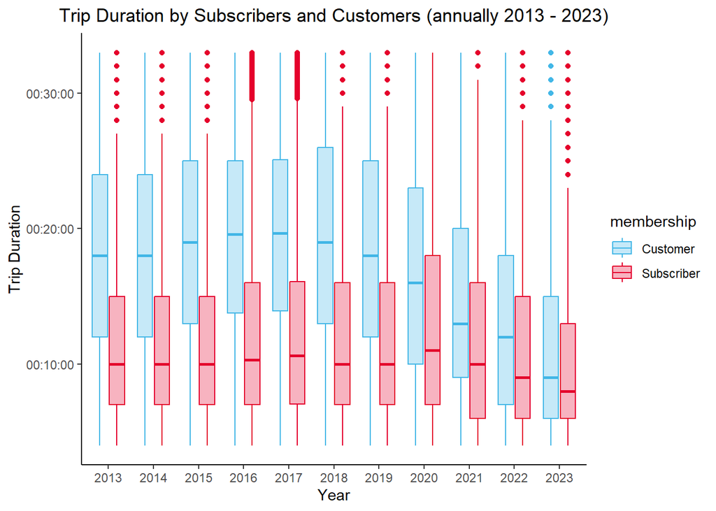

```r
  standard_deviantion = c(sd(ride_data$trip_duration[ride_data$membership == "Subscriber" & ride_data$start_year == 2013]),
                          sd(ride_data$trip_duration[ride_data$membership == "Customer" & ride_data$start_year == 2013]),
                          sd(ride_data$trip_duration[ride_data$membership == "Subscriber" & ride_data$start_year == 2014]),
                          sd(ride_data$trip_duration[ride_data$membership == "Customer" & ride_data$start_year == 2014]),
                          sd(ride_data$trip_duration[ride_data$membership == "Subscriber" & ride_data$start_year == 2015]),
                          sd(ride_data$trip_duration[ride_data$membership == "Customer" & ride_data$start_year == 2015]),
                          sd(ride_data$trip_duration[ride_data$membership == "Subscriber" & ride_data$start_year == 2016]),
                          sd(ride_data$trip_duration[ride_data$membership == "Customer" & ride_data$start_year == 2016]),
                          sd(ride_data$trip_duration[ride_data$membership == "Subscriber" & ride_data$start_year == 2017]),
                          sd(ride_data$trip_duration[ride_data$membership == "Customer" & ride_data$start_year == 2017]),
                          sd(ride_data$trip_duration[ride_data$membership == "Subscriber" & ride_data$start_year == 2018]),
                          sd(ride_data$trip_duration[ride_data$membership == "Customer" & ride_data$start_year == 2018]),
                          sd(ride_data$trip_duration[ride_data$membership == "Subscriber" & ride_data$start_year == 2019]),
                          sd(ride_data$trip_duration[ride_data$membership == "Customer" & ride_data$start_year == 2019]),
                          sd(ride_data$trip_duration[ride_data$membership == "Subscriber" & ride_data$start_year == 2020]),
                          sd(ride_data$trip_duration[ride_data$membership == "Customer" & ride_data$start_year == 2020]),
                          sd(ride_data$trip_duration[ride_data$membership == "Subscriber" & ride_data$start_year == 2021]),
                          sd(ride_data$trip_duration[ride_data$membership == "Customer" & ride_data$start_year == 2021]),
                          sd(ride_data$trip_duration[ride_data$membership == "Subscriber" & ride_data$start_year == 2022]),
                          sd(ride_data$trip_duration[ride_data$membership == "Customer" & ride_data$start_year == 2022]),
                          sd(ride_data$trip_duration[ride_data$membership == "Subscriber" & ride_data$start_year == 2023]),
                          sd(ride_data$trip_duration[ride_data$membership == "Customer" & ride_data$start_year == 2023]))
)
kable(tri_du_year, style = "rmarkdown")

# visualise the trip durations as scatter plots organised by years
# create a boxplot to compare the mean differences from 2013 to 2023.
p_tri_du_year_box <- ggplot(ride_data, aes(x =  as_factor(start_year), y = trip_duration, colour = membership, fill = membership)) +
  geom_boxplot(stat = "boxplot", alpha = 0.3) +
  scale_y_time(limits = quantile(ride_data$trip_duration, c(0.1, 0.9))) +
  xlab("Year") +
  ylab("Trip Duration") +
  ggtitle("Trip Duration by Subscribers and Customers (annually 2013 - 2023)") +
  scale_colour_manual(name = "membership", values = c("#41B6E6", "#E4002B")) +
  scale_fill_manual(name = "membership", values = c("#41B6E6", "#E4002B")) +
  theme_classic() +
  theme(plot.title = element_text(hjust = 0.5))
p_tri_du_year_box
```

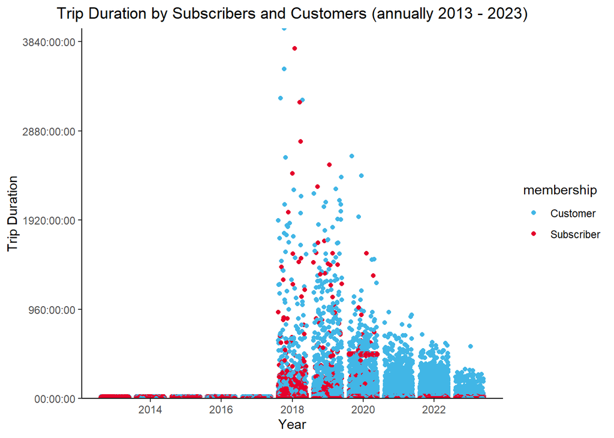

```r
# scatter points to visualise the entire data set.
ride_data$membership <- as.factor(ride_data$membership)
p_tri_du_point_year <- ggplot(ride_data, aes(x =  start_year, y = trip_duration, colour = membership)) +
  geom_jitter() +
  scale_y_time(expand = c(0, 0), limits = c(0, NA)) +
  xlab("Year") +
  ylab("Trip Duration") +
  ggtitle("Trip Duration by Subscribers and Customers (annually 2013 - 2023)") +
  scale_colour_manual(name = "membership", values = c("#41B6E6", "#E4002B")) +
  theme_classic() +
  theme(plot.title = element_text(hjust = 0.5))
p_tri_du_point_year
```

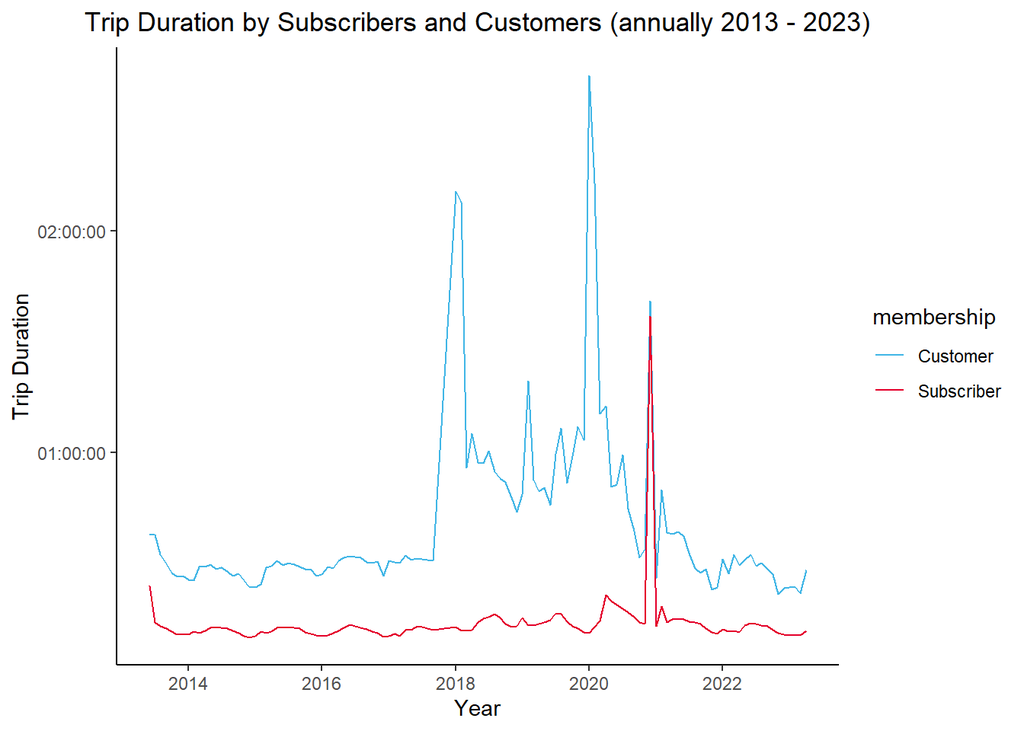

```r
invisible(gc())

# make a line plot to show changes from 2013 to 2023 explicitly.
tri_du_year <- ride_data %>%
  group_by(month = floor_date(start_datetime, 'month'), membership) %>%
  summarize(mean_tri_du = mean(trip_duration))
tri_du_year$membership <- as.factor(tri_du_year$membership)
tri_du_year$mean_tri_du <- as.numeric(tri_du_year$mean_tri_du)

p_tri_du_line_year <- ggplot(data = tri_du_year, aes(x = month, y = mean_tri_du, group = membership, color = membership)) +
  geom_line() +
  xlab("Year") +
  ylab("Trip Duration") +
  ggtitle("Trip Duration by Subscribers and Customers (annually 2013 - 2023)") +
  scale_colour_manual(name = "membership", values = c("#41B6E6", "#E4002B")) +
  scale_y_time() +
  theme_classic() +
  theme(plot.title = element_text(hjust = 0.5))
p_tri_du_line_year
```

```r
# we can see the mean trip durations are very close between subscriberse and customers in 2021

invisible(gc())
```

[output not shown]

Result of this section: (1) Subscribers overall have shorter trips compared to customers, though the gap of mean trip duration between the two membership is reduced since 2021.

Using statistic tests to examine whether the observed differences among the years are significant.

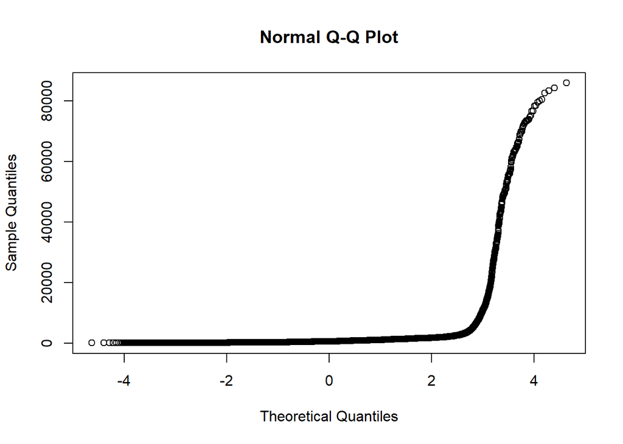

```r
# from the table, subscribers and customers have decent contrasts for means,
# median, and sd let's use a statistic test to see if we should be suprise to
# see the level of difference among years for subscribers and customers as we
# are interested in only the difference among years within subscribers and
# customers, we segregate the full data set into subscribers and customers.
# this makes computation a bit easier on my PC. You could perform two way anova
# or its non-parametric equivalent if you have a powerful PC.
qqnorm(ride_data$trip_duration[ride_data$membership == "Subscriber" & ride_data$start_year ==
    2013])
```

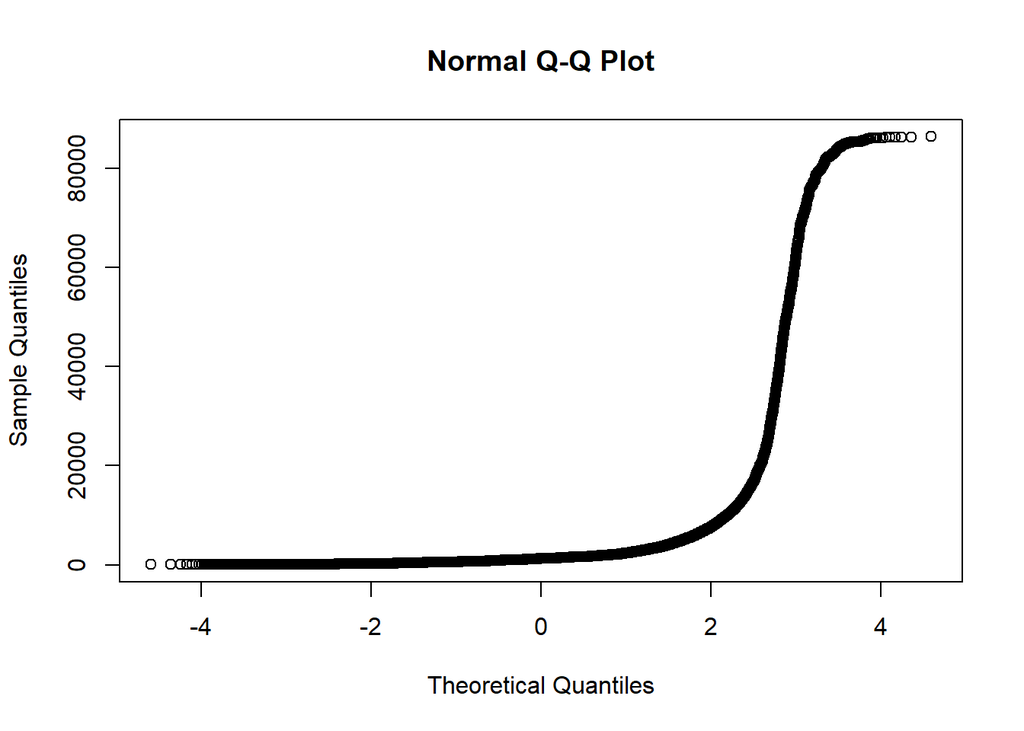

```r
# not normal.
qqnorm(ride_data$trip_duration[ride_data$membership == "Customer" & ride_data$start_year ==
    2013])
```

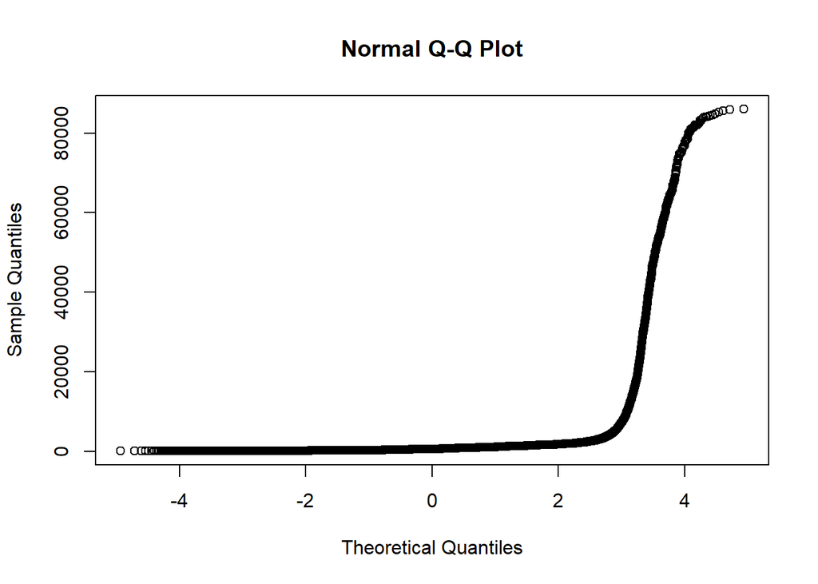

```r
# not normal.
qqnorm(ride_data$trip_duration[ride_data$membership == "Subscriber" & ride_data$start_year ==
    2014])
```

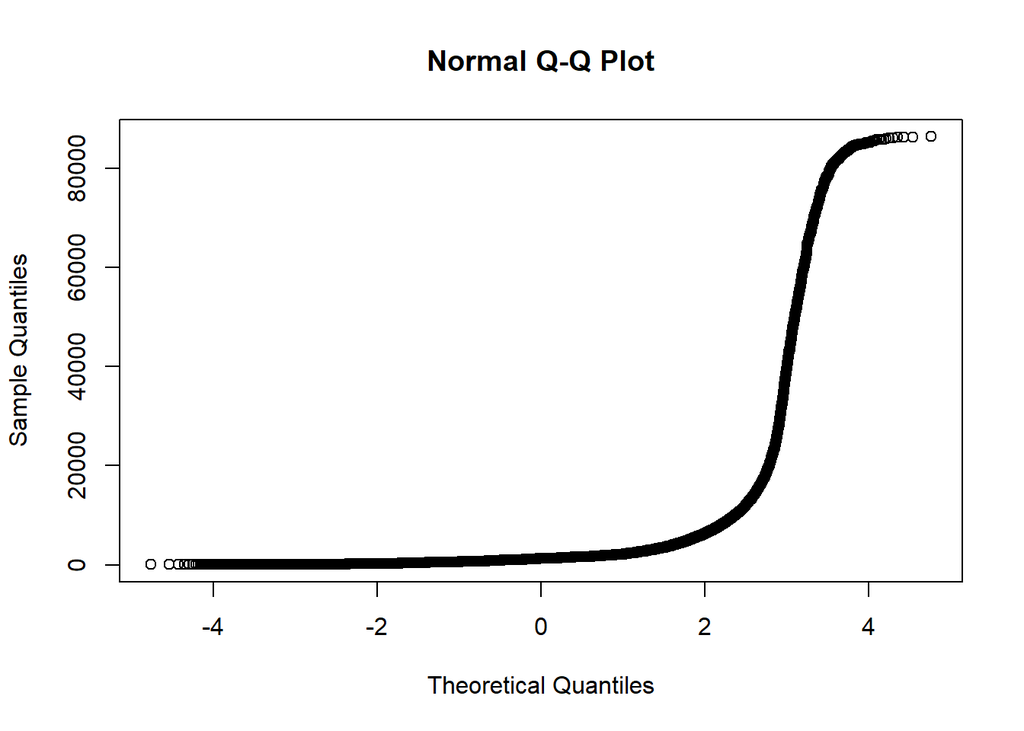

```r
# not normal.
qqnorm(ride_data$trip_duration[ride_data$membership == "Customer" & ride_data$start_year ==
    2014])
```

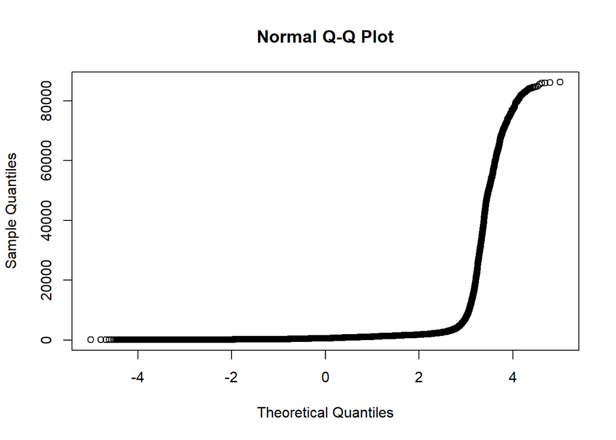

```r
# not normal.
qqnorm(ride_data$trip_duration[ride_data$membership == "Subscriber" & ride_data$start_year ==
    2015])
```

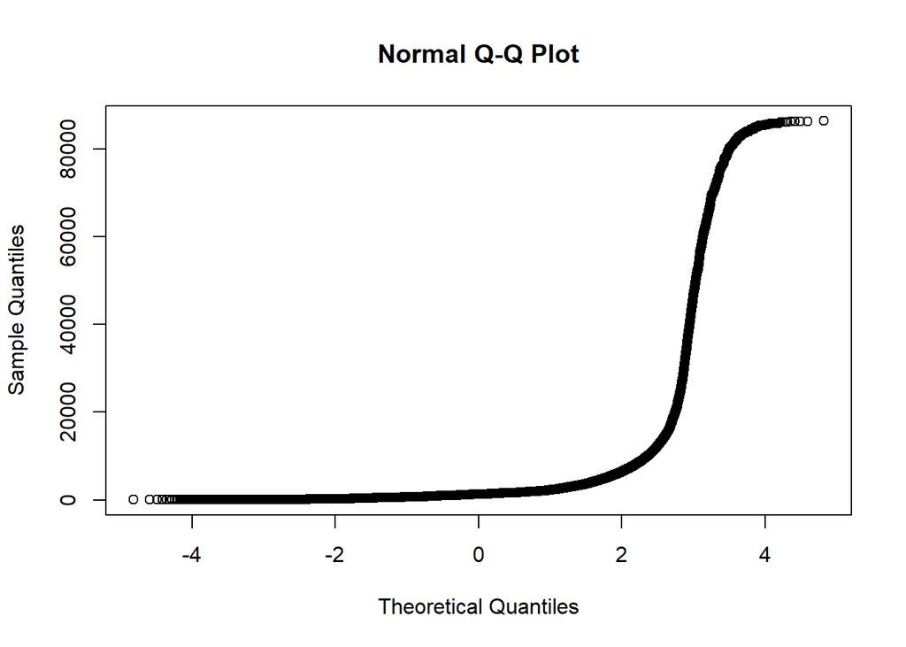

```r
# not normal.
qqnorm(ride_data$trip_duration[ride_data$membership == "Customer" & ride_data$start_year ==
    2015])
```

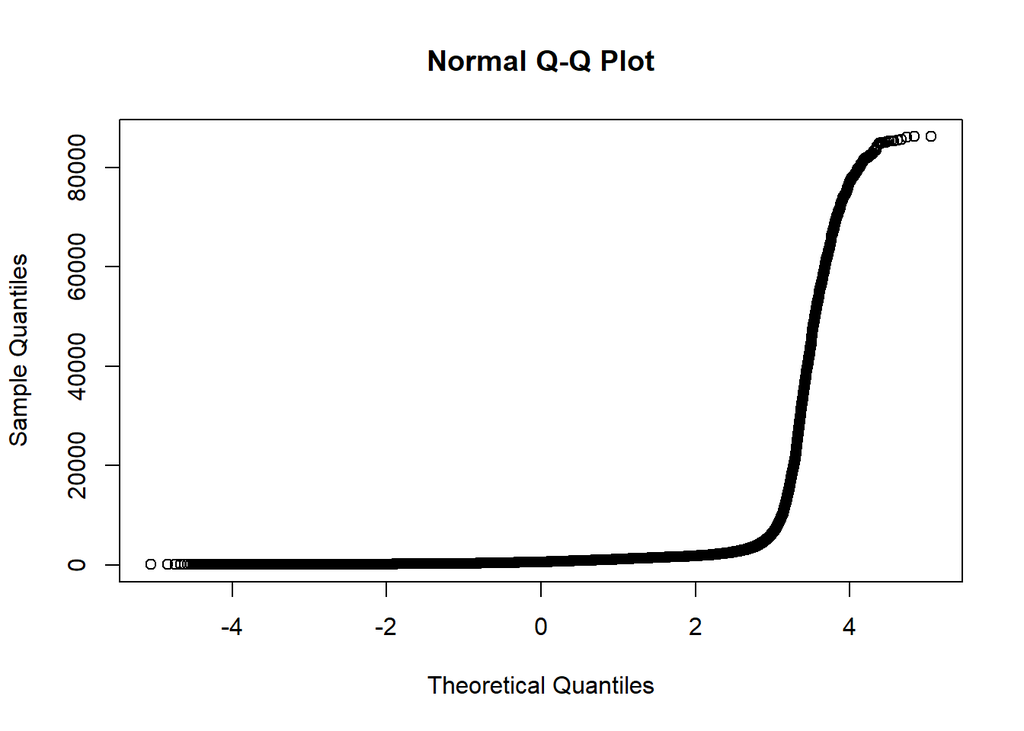

```r
# not normal.
qqnorm(ride_data$trip_duration[ride_data$membership == "Subscriber" & ride_data$start_year ==
    2016])
```

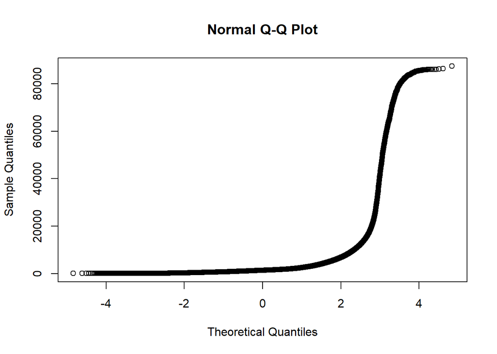

```r
# not normal.
qqnorm(ride_data$trip_duration[ride_data$membership == "Customer" & ride_data$start_year ==
    2016])
```

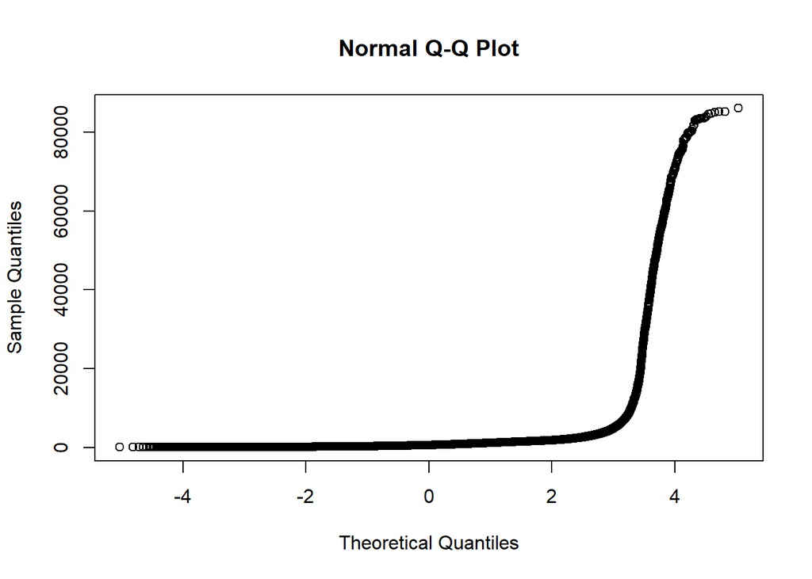

```r
# not normal.
qqnorm(ride_data$trip_duration[ride_data$membership == "Subscriber" & ride_data$start_year ==
    2017])
```

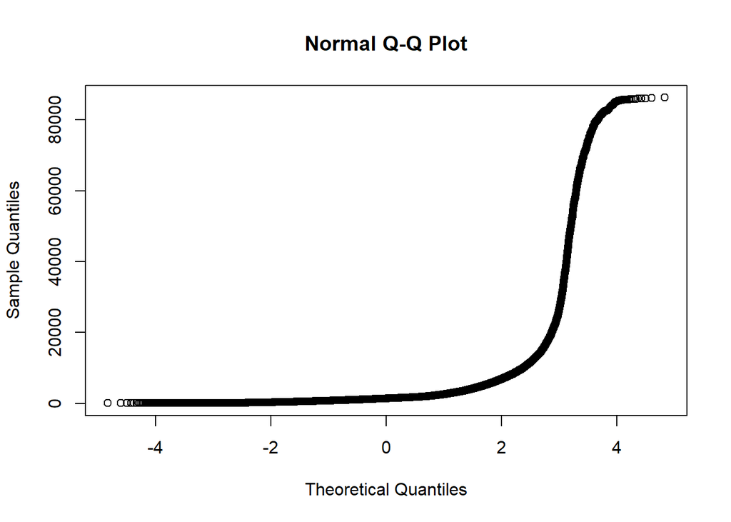

```r
# not normal.
qqnorm(ride_data$trip_duration[ride_data$membership == "Customer" & ride_data$start_year ==
    2017])
```

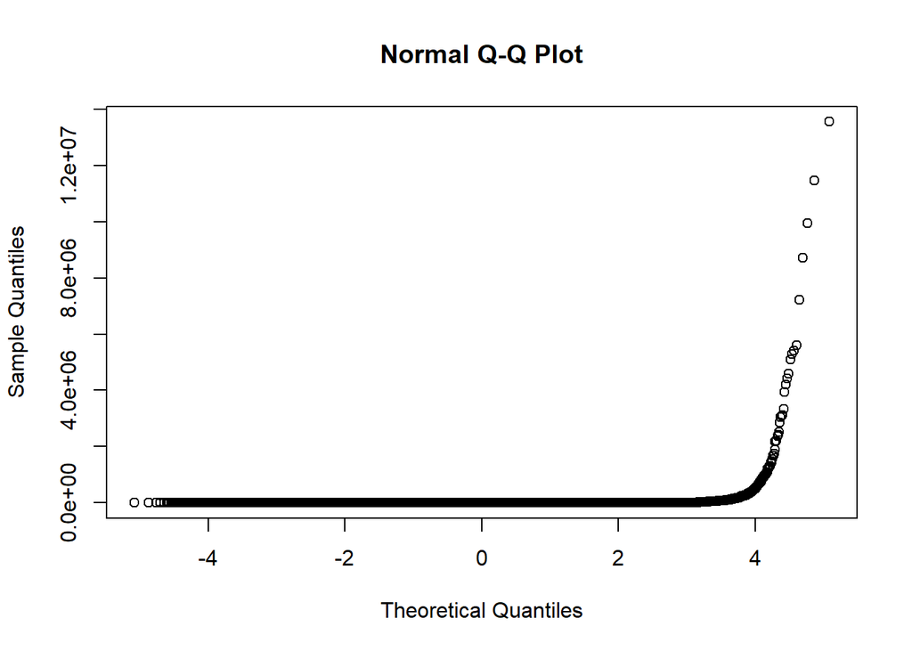

```r
# not normal.
qqnorm(ride_data$trip_duration[ride_data$membership == "Subscriber" & ride_data$start_year ==
    2018])
```

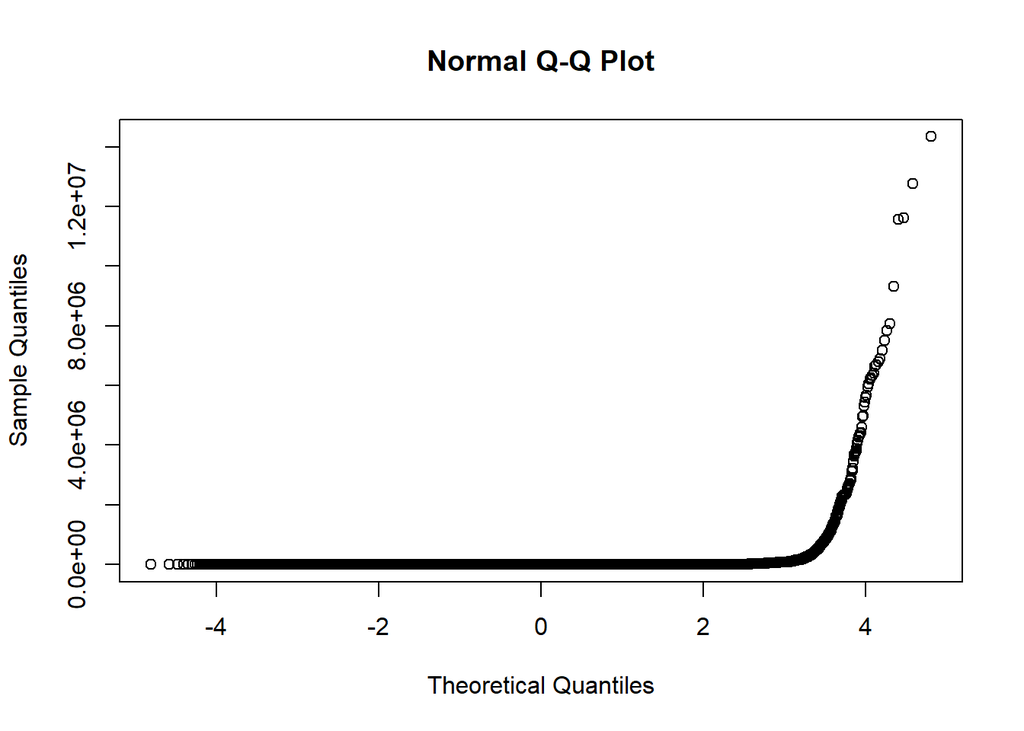

```r
# not normal.
qqnorm(ride_data$trip_duration[ride_data$membership == "Customer" & ride_data$start_year ==
    2018])
```

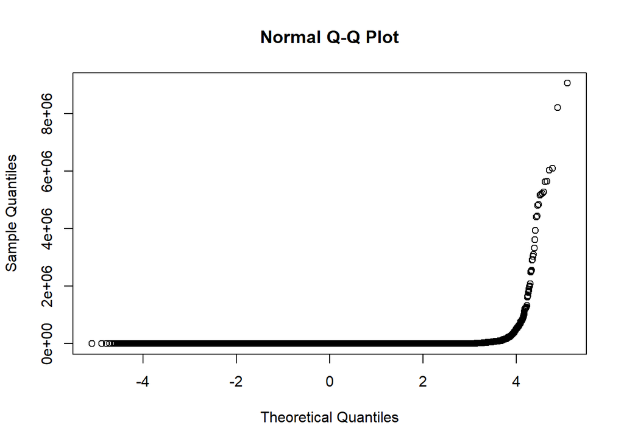

```r
# not normal.
qqnorm(ride_data$trip_duration[ride_data$membership == "Subscriber" & ride_data$start_year ==
    2019])
```

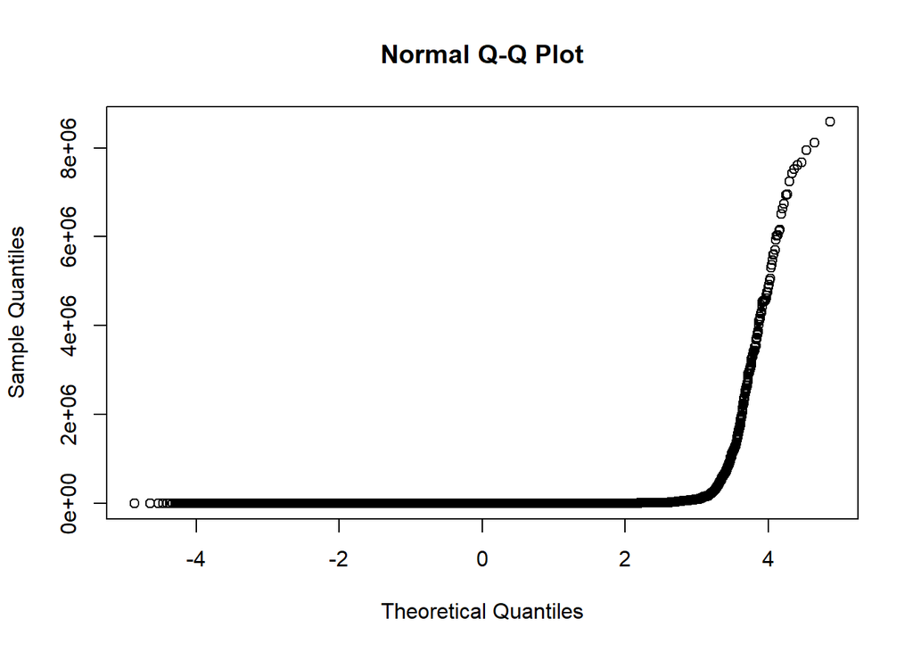

```r
# not normal.
qqnorm(ride_data$trip_duration[ride_data$membership == "Customer" & ride_data$start_year ==
    2019])
```

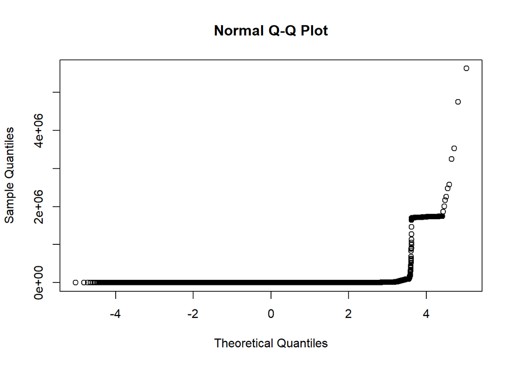

```r
# not normal.
qqnorm(ride_data$trip_duration[ride_data$membership == "Subscriber" & ride_data$start_year ==
    2020])
```

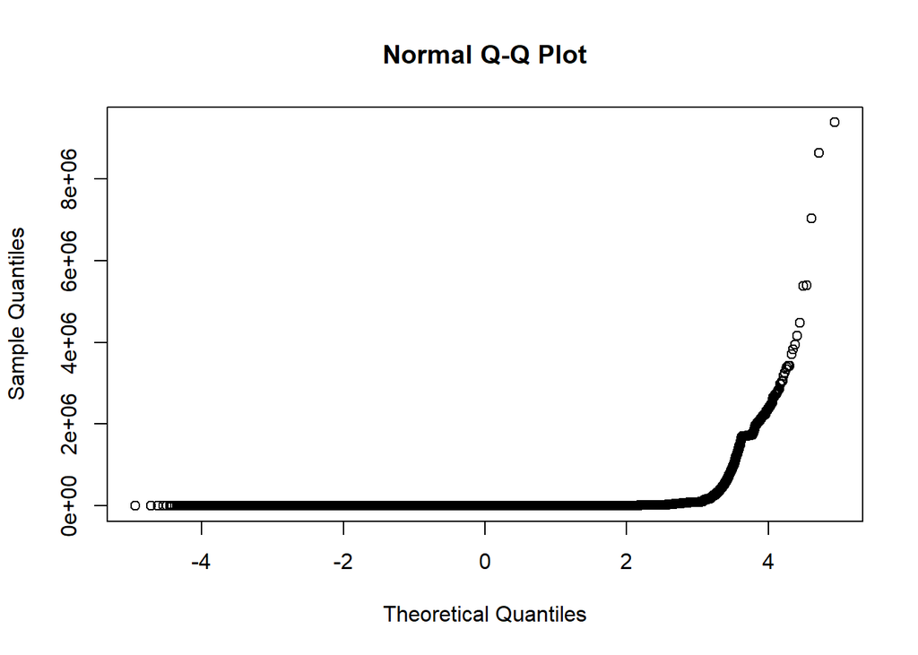

```r
# not normal.
qqnorm(ride_data$trip_duration[ride_data$membership == "Customer" & ride_data$start_year ==
    2020])
```

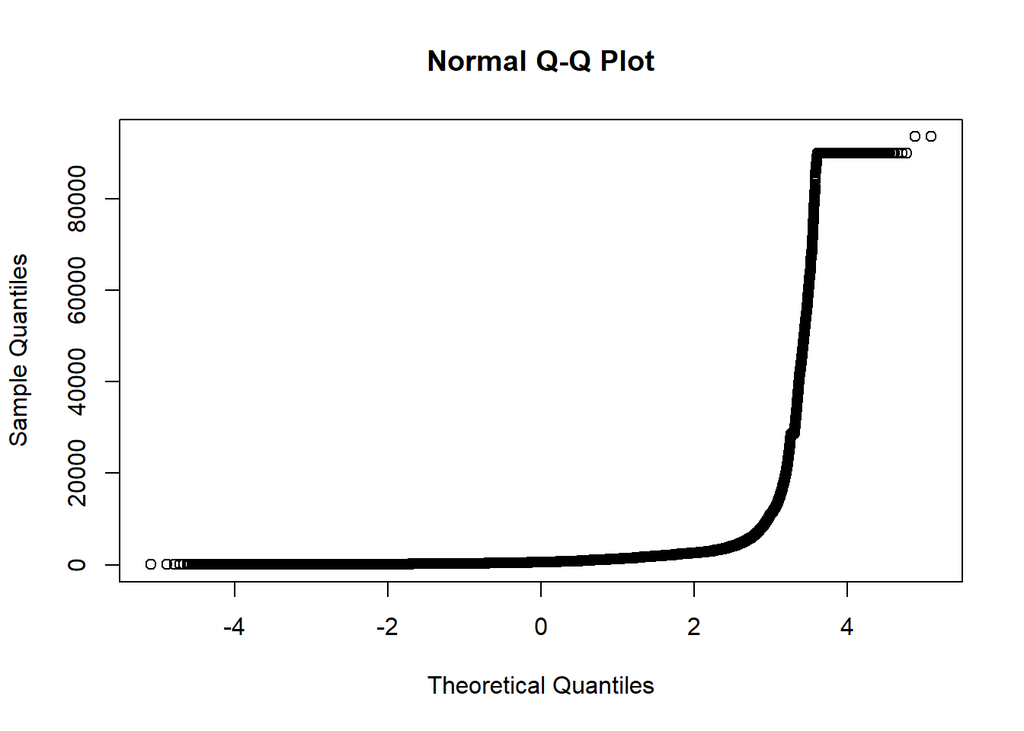

```r
# not normal.
qqnorm(ride_data$trip_duration[ride_data$membership == "Subscriber" & ride_data$start_year ==
    2021])
```

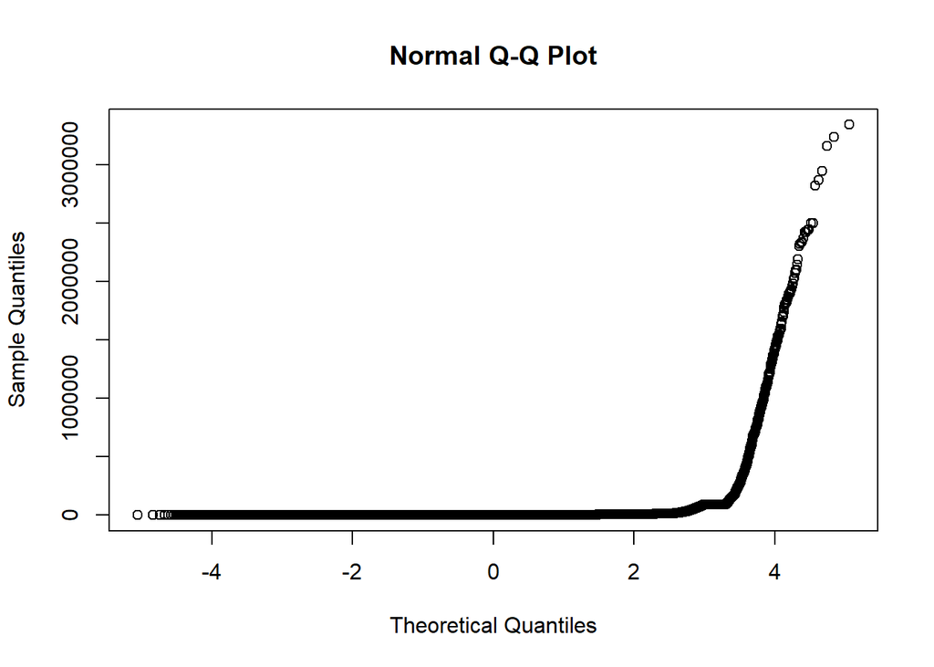

```r
# not normal.
qqnorm(ride_data$trip_duration[ride_data$membership == "Customer" & ride_data$start_year ==
    2021])
```

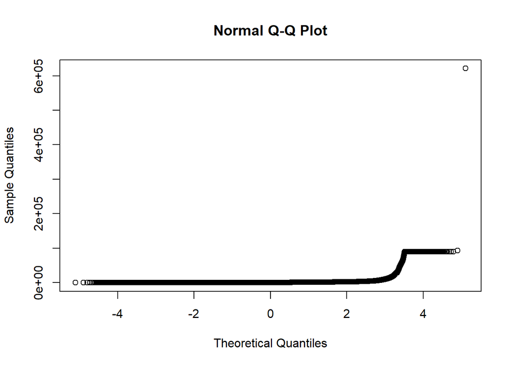

```r
# not normal.
qqnorm(ride_data$trip_duration[ride_data$membership == "Subscriber" & ride_data$start_year ==
    2022])
```

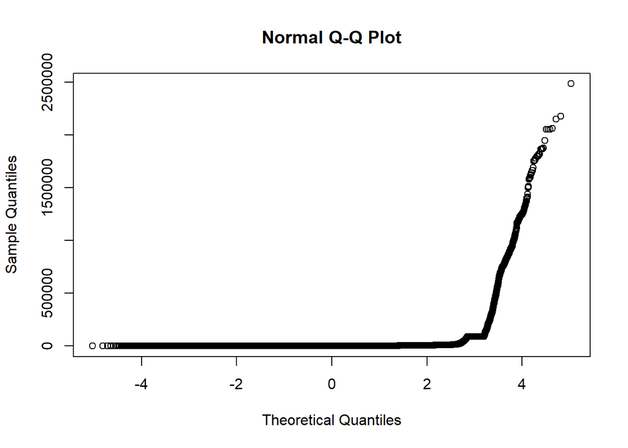

```r
# not normal.
qqnorm(ride_data$trip_duration[ride_data$membership == "Customer" & ride_data$start_year ==
    2022])
```